title: “Haciendo Big Data a League of Legends” author: “Jorge de Andrés” date: “16 de enero de 2019” output: html_document: default word_document: default pdf_document: default

Limpiamos environment:

```r
rm(list=ls())
```

Importamos los paquetes necesarios:

```r
#install.packages("knitr")
#install.packages("dplyr")
#install.packages("pryr")
#install.packages("corrplot")
#install.packages("rjson")
#install.packages("plyr")
#install.packages("wordcloud")
#install.packages("ggplot2")
#install.packages("hexbin")
#install.packages("RColorBrewer")
#install.packages("FactoMineR")
#devtools::install_github("kassambara/factoextra")
#install.packages("factoextra")
#install.packages("arules")
#install.packages("arulesViz")
#install.packages("fastDummies")
#install.packages("caret")
#install.packages("nnet")
#install.packages("gmodels")
#install.packages("class")
#install.packages("randomforest")
#install.packages("e1071")
#install.packages("aplpack")
#install.packages("cluster")
#install.packages("fpc")
#install.packages("purrr")
#install.packages("RWeka")

library("corrplot")
library("dplyr")
library("pryr")
library("rjson")
library("plyr")
library("wordcloud")
library("ggplot2")
library("hexbin")
library("RColorBrewer")
library("FactoMineR")
library("factoextra")
require("arulesViz")
require("arules")
library("Matrix")
library("fastDummies")
library("caret")
library("nnet")
library("gmodels")
library("class")
library("randomForest")
library("e1071")
library("aplpack")
library("cluster")
library("fpc")
library("purrr")
library("RWeka")
library("data.table")
```

Lo primero que voy a hacer es importar todos los datasets:

```r
data.games <- read.csv("../../data/games.csv")
data.champs <- read.csv("../../data/champs.csv")
```

Hemos importado varios CSV que harán las tablas de la base de datos.

Importamos los json:

```r
lista.championInfo <- fromJSON(file = "../../data/champion_info.json")
lista.championInfo2 <- fromJSON(file="../../data/champion_info_2.json")
lista.summonerSpell <- fromJSON(file="../../data/summoner_spell_info.json")
```

Tamaño de mis datasets…

```r
print( paste0("El tamaño de la tabla de games es de: "))
```

```
## [1] "El tamaño de la tabla de games es de: "
```

```r
object_size(data.games)
```

```
## 13 MB
```

Esto me devuelve las filas que tengan NA:

```r
data.games[!complete.cases(data.games),]
```

```
##  [1] gameId             creationTime       gameDuration
##  [4] seasonId           winner             firstBlood
##  [7] firstTower         firstInhibitor     firstBaron
## [10] firstDragon        firstRiftHerald    t1_champ1id
## [13] t1_champ1_sum1     t1_champ1_sum2     t1_champ2id
## [16] t1_champ2_sum1     t1_champ2_sum2     t1_champ3id
## [19] t1_champ3_sum1     t1_champ3_sum2     t1_champ4id
## [22] t1_champ4_sum1     t1_champ4_sum2     t1_champ5id
## [25] t1_champ5_sum1     t1_champ5_sum2     t1_towerKills
## [28] t1_inhibitorKills  t1_baronKills      t1_dragonKills
## [31] t1_riftHeraldKills t1_ban1            t1_ban2
## [34] t1_ban3            t1_ban4            t1_ban5
## [37] t2_champ1id        t2_champ1_sum1     t2_champ1_sum2
## [40] t2_champ2id        t2_champ2_sum1     t2_champ2_sum2
## [43] t2_champ3id        t2_champ3_sum1     t2_champ3_sum2
## [46] t2_champ4id        t2_champ4_sum1     t2_champ4_sum2
## [49] t2_champ5id        t2_champ5_sum1     t2_champ5_sum2
## [52] t2_towerKills      t2_inhibitorKills  t2_baronKills
## [55] t2_dragonKills     t2_riftHeraldKills t2_ban1
## [58] t2_ban2            t2_ban3            t2_ban4
## [61] t2_ban5
## <0 rows> (or 0-length row.names)
```

Como podemos ver, no tenemos filas con NA.

Como voy a ir haciendo “pequeños proyectos” para ir sacando conocimiento por ahora no voy a fusionar ninguna tabla de primeras porque no se lo que voy a necesitar. Según se vayan planteando los interrogantes iré jugando con las tablas para conseguir los objetivos

# Análisis Exploratorio

Empezamos por el análisis exploratorio de los datos. Para ello, vamos intentar ver conclusiones sobre los mismos:

```r
print("Resumen de data.games")
```

```
## [1] "Resumen de data.games"
```

```r
summary(data.games) # Las únicas columnas interesantes son la 5 y la 6
```

```
##      gameId           creationTime        gameDuration     seasonId
##  Min.   :3.215e+09   Min.   :1.497e+12   Min.   : 190   Min.   :9
##  1st Qu.:3.292e+09   1st Qu.:1.502e+12   1st Qu.:1531   1st Qu.:9
##  Median :3.320e+09   Median :1.504e+12   Median :1833   Median :9
##  Mean   :3.306e+09   Mean   :1.503e+12   Mean   :1832   Mean   :9
##  3rd Qu.:3.327e+09   3rd Qu.:1.504e+12   3rd Qu.:2148   3rd Qu.:9
##  Max.   :3.332e+09   Max.   :1.505e+12   Max.   :4728   Max.   :9
##      winner        firstBlood      firstTower    firstInhibitor
##  Min.   :1.000   Min.   :0.000   Min.   :0.000   Min.   :0.000
##  1st Qu.:1.000   1st Qu.:1.000   1st Qu.:1.000   1st Qu.:1.000
##  Median :1.000   Median :1.000   Median :1.000   Median :1.000
##  Mean   :1.494   Mean   :1.471   Mean   :1.451   Mean   :1.308
##  3rd Qu.:2.000   3rd Qu.:2.000   3rd Qu.:2.000   3rd Qu.:2.000
##  Max.   :2.000   Max.   :2.000   Max.   :2.000   Max.   :2.000
##    firstBaron      firstDragon    firstRiftHerald   t1_champ1id
##  Min.   :0.0000   Min.   :0.000   Min.   :0.0000   Min.   :  1.0
##  1st Qu.:0.0000   1st Qu.:1.000   1st Qu.:0.0000   1st Qu.: 35.0
##  Median :1.0000   Median :1.000   Median :0.0000   Median : 79.0
##  Mean   :0.9265   Mean   :1.443   Mean   :0.7317   Mean   :114.3
##  3rd Qu.:2.0000   3rd Qu.:2.000   3rd Qu.:1.0000   3rd Qu.:136.0
##  Max.   :2.0000   Max.   :2.000   Max.   :2.0000   Max.   :516.0
##  t1_champ1_sum1   t1_champ1_sum2    t1_champ2id    t1_champ2_sum1
##  Min.   : 1.000   Min.   : 1.000   Min.   :  1.0   Min.   : 1.000
##  1st Qu.: 4.000   1st Qu.: 4.000   1st Qu.: 35.0   1st Qu.: 4.000
##  Median : 4.000   Median : 4.000   Median : 79.0   Median : 4.000
##  Mean   : 6.602   Mean   : 7.334   Mean   :118.1   Mean   : 6.548
##  3rd Qu.:11.000   3rd Qu.:11.000   3rd Qu.:141.0   3rd Qu.:11.000
##  Max.   :21.000   Max.   :21.000   Max.   :516.0   Max.   :21.000
##  t1_champ2_sum2    t1_champ3id    t1_champ3_sum1   t1_champ3_sum2
##  Min.   : 1.000   Min.   :  1.0   Min.   : 1.000   Min.   : 1.000
##  1st Qu.: 4.000   1st Qu.: 35.0   1st Qu.: 4.000   1st Qu.: 4.000
##  Median : 4.000   Median : 78.0   Median : 4.000   Median : 4.000
##  Mean   : 7.198   Mean   :116.9   Mean   : 6.542   Mean   : 7.201
##  3rd Qu.:11.000   3rd Qu.:141.0   3rd Qu.:11.000   3rd Qu.:11.000
##  Max.   :21.000   Max.   :516.0   Max.   :21.000   Max.   :21.000
##   t1_champ4id    t1_champ4_sum1   t1_champ4_sum2    t1_champ5id
##  Min.   :  1.0   Min.   : 1.000   Min.   : 1.000   Min.   :  1.0
##  1st Qu.: 36.0   1st Qu.: 4.000   1st Qu.: 4.000   1st Qu.: 35.0
##  Median : 79.0   Median : 4.000   Median : 4.000   Median : 78.0
##  Mean   :117.7   Mean   : 6.531   Mean   : 7.221   Mean   :114.6
```

[output cut: 57 more lines]

```
##  Max.   :10.0000   Max.   :4.0000   Max.   :6.000   Max.   :1.0000
##     t2_ban1         t2_ban2         t2_ban3         t2_ban4
##  Min.   : -1.0   Min.   : -1.0   Min.   : -1.0   Min.   : -1.0
##  1st Qu.: 38.0   1st Qu.: 37.0   1st Qu.: 38.0   1st Qu.: 38.0
##  Median : 90.0   Median : 90.0   Median : 90.0   Median : 90.0
##  Mean   :108.2   Mean   :107.9   Mean   :108.7   Mean   :108.6
##  3rd Qu.:141.0   3rd Qu.:141.0   3rd Qu.:141.0   3rd Qu.:141.0
##  Max.   :516.0   Max.   :516.0   Max.   :516.0   Max.   :516.0
##     t2_ban5
##  Min.   : -1.0
##  1st Qu.: 38.0
##  Median : 90.0
##  Mean   :108.1
##  3rd Qu.:141.0
##  Max.   :516.0
```

Una vez que tenemos los estadísticos básicos principales, vamos a limpiar algunos datasets de variables que no necesitamos para poder hacer análisis de variables con su correlación y similares…

```r
# Ahora voy a hacer una tabla de games especial solo con las variables de las que calcularemos las correlaciones
# Game ID es una variable que no necesito para nada, por lo que la voy a eliminar:

data.games.corr <- data.games[, c(-1, -4)]
#head(data.games.corr)
data.games.corr <- data.games.corr[, -10:-24]
#head(data.games.corr)
data.games.corr <- data.games.corr[, -15:-34]
#head(data.games.corr)
data.games.corr <- data.games.corr[, -20:-24]
```

## Correlation Plots

Lo primero que voy a hacer son los correlation plot de cada una de las tablas. Vamos a ver qué relaciones tenemos entre los datos, para poder ver si podemos ir sacando algunas conclusiones…

```r
res.games <- cor(data.games.corr, method = "spearman")
options(width = 100)
res.games.round <- round(res.games, 2)
```

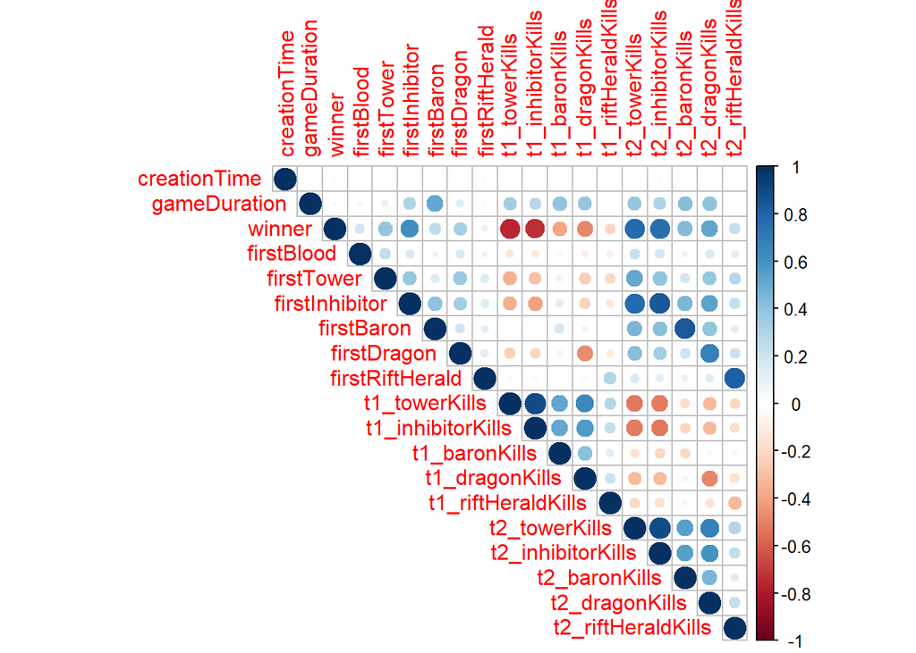

```r
corrplot(res.games.round, method="circle", type = "upper")
```

Exportamos el corrplot a PDF para tenerlo vectorial y poderlo ver mejor…

```r
pdf("../imagenes/corrplot.pdf")
corrplot(res.games.round, method="circle", type = "upper")
dev.off
```

```
## function (which = dev.cur())
## {
##     if (which == 1)
##         stop("cannot shut down device 1 (the null device)")
##     .External(C_devoff, as.integer(which))
##     dev.cur()
## }
## <bytecode: 0x0000000016564710>
## <environment: namespace:grDevices>
```

Podemos apreciar las siguientes correlaciones sobre destruir torres:

- Destruir más torres tiene una relación directa con destruir inhibidores
- Destruir más torres tiene una cierta relación directa con matar dragones
- Destruir más torres tiene una cierta relación inversa con que el equipo contrario destruya tus torres
- Destruir más torres tiene uan cierta relación con que el equipo contrario mate menos dragones

Respecto a ganar, obtenemos las siguientes correlaciones:

- Muchas veces, quien destruye el primer inhibidor es el equipo que acaba ganando la partida
- Un aumento en que el equipo 1 destruya más torres tiene que ver con que tengan más posibilidades de victoria. Esto se da con una relación inversa, ya que la victoria del equipo 1 se marca con un 1, la del 2 con un dos, y el aumento de towerkills de t1 implica una bajada en win (1 en vez de dos)
- Lo mismi pasa con la cantidad de inhibidores destruidos, donde es también una relación muy fuerte la que hay.
- Con el equipo 2 pasa lo mismo, lo que pasa es que, por lo explicado anteriormente, en este caso se muestra como relación direta, y de este modo podemos ver las mismas correlaciones de una parte que de otra.

Respecto a dragones, podemos ver:

- Es más importante para el equipo 2 hacerse el primer dragón de cara a hacerse más que el que el equipo 1 haga el mismo.

Finalmente, respecto a el momento de la creación de la partida, podemos observar:

- No tiene ninguna relación el paso del tiempo cno el aumento o disminución de ninguna de las variables.

## PCA

Vamos a hacer ahora un análisis de las componentes principales: Para los cálculos, uso la matriz con el centrado y escalado ya hechos

```r
resultado.pca <- PCA(data.games.corr, graph = FALSE)

#Con la siguiente línea podemos ver que podemos hacer con esto calculado
print(resultado.pca)
```

```
## **Results for the Principal Component Analysis (PCA)**
## The analysis was performed on 51490 individuals, described by 19 variables
## *The results are available in the following objects:
##
##    name               description
## 1  "$eig"             "eigenvalues"
## 2  "$var"             "results for the variables"
## 3  "$var$coord"       "coord. for the variables"
## 4  "$var$cor"         "correlations variables - dimensions"
## 5  "$var$cos2"        "cos2 for the variables"
## 6  "$var$contrib"     "contributions of the variables"
## 7  "$ind"             "results for the individuals"
## 8  "$ind$coord"       "coord. for the individuals"
## 9  "$ind$cos2"        "cos2 for the individuals"
## 10 "$ind$contrib"     "contributions of the individuals"
## 11 "$call"            "summary statistics"
## 12 "$call$centre"     "mean of the variables"
## 13 "$call$ecart.type" "standard error of the variables"
## 14 "$call$row.w"      "weights for the individuals"
## 15 "$call$col.w"      "weights for the variables"
```

Nos interesa ver los eigenvalues, que son los que presentarán la cantidad de varianza que aportan las variables:

```r
eigenvalues.PCA <- resultado.pca$eig
eigenvalues.PCA
```

```
##           eigenvalue percentage of variance cumulative percentage of variance
## comp 1  6.064459e+00           3.191820e+01                          31.91820
## comp 2  3.000738e+00           1.579336e+01                          47.71156
## comp 3  1.771844e+00           9.325495e+00                          57.03706
## comp 4  1.316075e+00           6.926710e+00                          63.96377
## comp 5  1.066890e+00           5.615210e+00                          69.57898
## comp 6  9.958756e-01           5.241450e+00                          74.82043
## comp 7  9.704525e-01           5.107645e+00                          79.92807
## comp 8  8.740157e-01           4.600083e+00                          84.52816
## comp 9  6.403057e-01           3.370030e+00                          87.89819
## comp 10 5.797901e-01           3.051527e+00                          90.94971
## comp 11 4.053622e-01           2.133485e+00                          93.08320
## comp 12 3.670873e-01           1.932039e+00                          95.01524
## comp 13 2.816983e-01           1.482623e+00                          96.49786
## comp 14 2.465127e-01           1.297435e+00                          97.79529
## comp 15 1.253587e-01           6.597825e-01                          98.45508
## comp 16 1.175431e-01           6.186477e-01                          99.07372
## comp 17 1.007805e-01           5.304239e-01                          99.60415
## comp 18 7.521185e-02           3.958518e-01                         100.00000
## comp 19 7.248996e-26           3.815261e-25                         100.00000
```

Como podemos ver, tenemos 19 componentes principales (una por cada dimensión), y vemos que solo con 10 variables ya tenemos un 90% de explicación. Además, de cara a la representación en dos dimensiones, podemos ver que con solo las dos variables con más varianza tenemos una explicación del 47,7%.

Ahora, para completar este apartado de PCA, lo que voy a hacer es sacar la gráfica de la varianza acumulada con los valores anteriores:

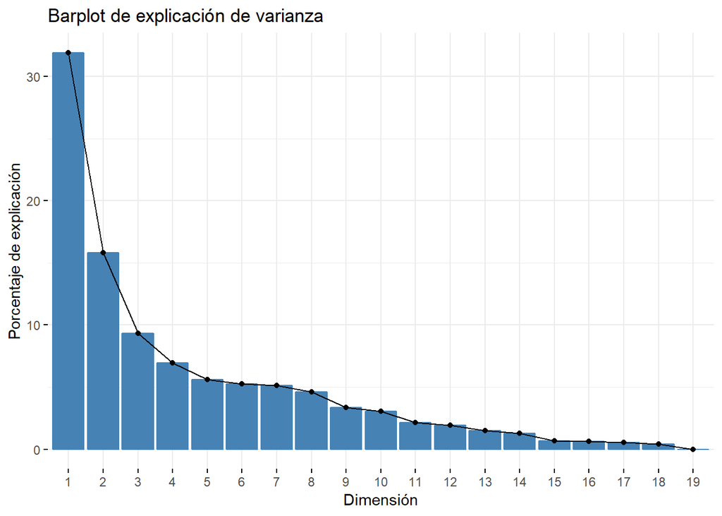

```r
plotPCA <- fviz_screeplot(resultado.pca, ncp=19, main="Barplot de explicación de varianza", ylab="Porcentaje de explicación", xlab="Dimensión")
plot(plotPCA)
```

Ahora voy a sacar un “Factor Map” de las variables. Esto lo puedo hacer gracias a las coordenadas que me da una de las variables tras hacer el PCA. Así, voy primero a ver la tabla y luego voy a sacar el mapa:

```r
head(resultado.pca$var$coord)
```

```
##                     Dim.1       Dim.2       Dim.3       Dim.4       Dim.5
## creationTime   0.01723817 -0.01149443 -0.06290260  0.04393011 -0.25111184
## gameDuration   0.24050089  0.86002372 -0.09989262  0.13764973 -0.07795331
## winner         0.84048823 -0.23457181 -0.14685233 -0.11282396 -0.04006251
## firstBlood     0.26968344  0.05182651  0.13357189  0.34780625 -0.23151329
## firstTower     0.55683600  0.07472362  0.19566560  0.37066228 -0.14932506
## firstInhibitor 0.72099264  0.28414084 -0.07367165 -0.02461892 -0.03806185
```

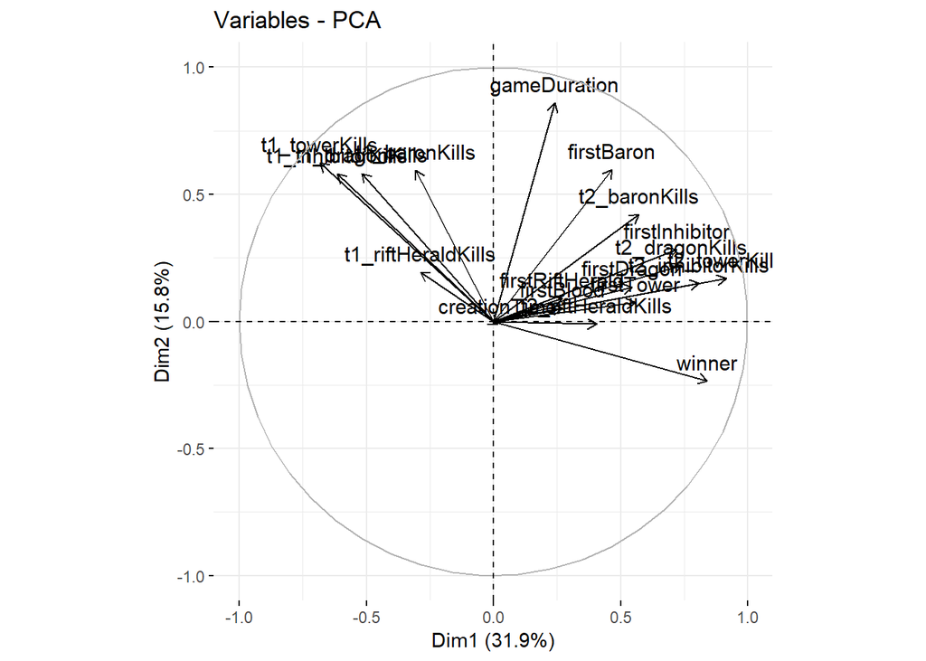

```r
fviz_pca_var(resultado.pca)
```

Es interesante ver como no hay nada que vaya en la misma dirección que la victoria. T1 tiene que ser interpretado de una manera en espejo respecto al eje de las Y, y vemos como muchísimas variables como el heraldo, first blood, número de dragones… todas tienen más o menos la misma importancia de cara a conseguir la victoria.

Vemos como la duración del juego forma un ángulo de 90 grados con la victoria, lo cual significa que no tiene nada que ver.

Ahora vamos a ver en un mapa, sobre las dos componentes principales, todas las partidas:

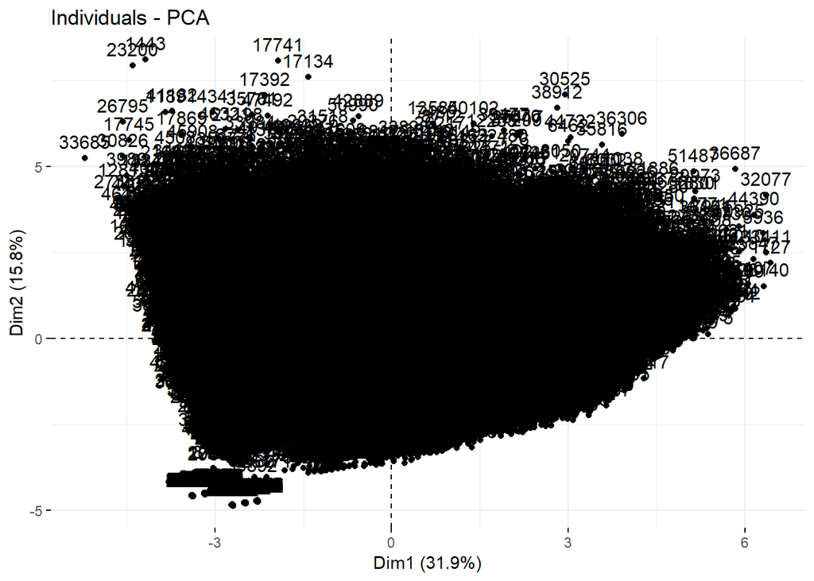

```r
fviz_pca_ind(resultado.pca)
```

Exportamos estos gráficos del PCA de los individuos…

```r
pdf("../imagenes/PCAIndividuos.pdf")

plot(plotPCA)
fviz_pca_var(resultado.pca)
fviz_pca_ind(resultado.pca)

dev.off
```

```
## function (which = dev.cur())
## {
##     if (which == 1)
##         stop("cannot shut down device 1 (the null device)")
##     .External(C_devoff, as.integer(which))
##     dev.cur()
## }
## <bytecode: 0x0000000016564710>
## <environment: namespace:grDevices>
```

Como se puede apreciar en este gráfico también, prácticamente todas las partidas forman un gran cluster (representado sobre las dos componentes con más variabilidad), y esto nos demuestra que no hay demasiada varianza entre unas partidas y otras. En otras palabras, no podemos distinguir fácilmente varios tipos de partidas, todas son parecidas y no hay diferencias suficientes para clasificar en grupos, más que en uno grande.

Para analizar la variabilidad de algunas partidas, vamos a verlo mediante el método de las caras de Chernoff:

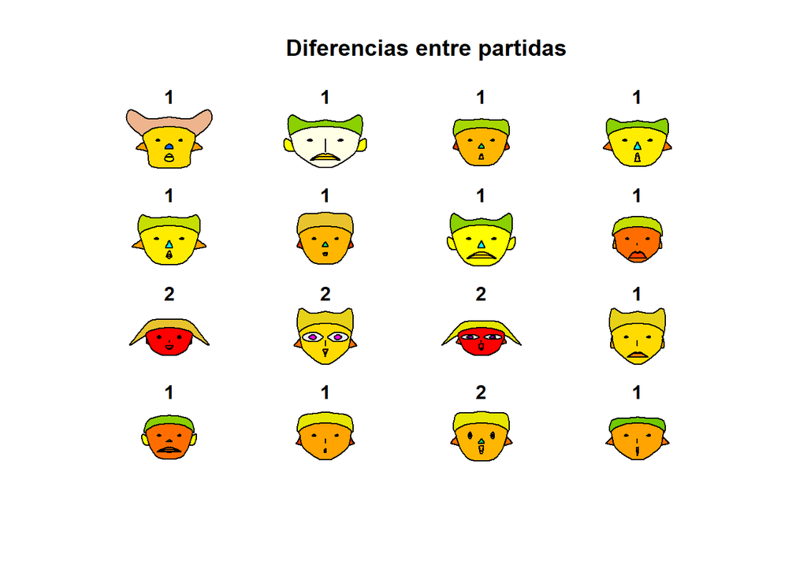

```
## effect of variables:
##  modified item       Var
##  "height of face   " "t1_towerKills"
##  "width of face    " "t1_inhibitorKills"
##  "structure of face" "t1_baronKills"
##  "height of mouth  " "t1_dragonKills"
##  "width of mouth   " "t1_riftHeraldKills"
##  "smiling          " "t2_towerKills"
##  "height of eyes   " "t2_inhibitorKills"
##  "width of eyes    " "t2_baronKills"
##  "height of hair   " "t2_dragonKills"
##  "width of hair   "  "t2_riftHeraldKills"
##  "style of hair   "  "t1_towerKills"
##  "height of nose  "  "t1_inhibitorKills"
##  "width of nose   "  "t1_baronKills"
##  "width of ear    "  "t1_dragonKills"
##  "height of ear   "  "t1_riftHeraldKills"
```

```r
muestra_partidas <- data.games[1:16, 27:31]
muestra_partidas <- cbind(muestra_partidas, data.games[1:16, 52:56])
faces(muestra_partidas[1:10], face.type=1,labels=data.games[1:16, 5], main = "Diferencias entre partidas", scale = TRUE, cex = 1.5)
```

Lo exportamos a PDF para tener más calidad al pasarlo a vectorial…

```r
pdf("../imagenes/chernoff partidas.pdf")
faces(muestra_partidas[1:10], face.type=1,labels=data.games[1:16, 5], main = "Diferencias entre partidas", scale = TRUE, cex = 1.5)
```

```
## effect of variables:
##  modified item       Var
##  "height of face   " "t1_towerKills"
##  "width of face    " "t1_inhibitorKills"
##  "structure of face" "t1_baronKills"
##  "height of mouth  " "t1_dragonKills"
##  "width of mouth   " "t1_riftHeraldKills"
##  "smiling          " "t2_towerKills"
##  "height of eyes   " "t2_inhibitorKills"
##  "width of eyes    " "t2_baronKills"
##  "height of hair   " "t2_dragonKills"
##  "width of hair   "  "t2_riftHeraldKills"
##  "style of hair   "  "t1_towerKills"
##  "height of nose  "  "t1_inhibitorKills"
##  "width of nose   "  "t1_baronKills"
##  "width of ear    "  "t1_dragonKills"
##  "height of ear   "  "t1_riftHeraldKills"
```

```r
dev.off
```

```
## function (which = dev.cur())
## {
##     if (which == 1)
##         stop("cannot shut down device 1 (the null device)")
##     .External(C_devoff, as.integer(which))
##     dev.cur()
## }
## <bytecode: 0x0000000016564710>
## <environment: namespace:grDevices>
```

Como podemos ver, hay diferencias entre las partidas ganadas por el equipo 1 (caras en general más grandes y geométricas, pelo hacia arriba) y las del equipo 2 (pelo hacia abajo y amarillo, cara roja en la mitad, cara redondeada…)

## Preguntas

Ahora que tenemos las correlaciones vistas, podemos pasar a hacernos preguntas.

### ¿Campeón más baneado por temporada?

Uno de los elementos que más se tienen en cuenta a la hora de analizar el League of Legends en los e-sports es el campeón más baneado por temporada o campeonato. Esto es porque desde Riot Games hacen cambios a las habilidades y fuerza de los personajes, de tal manera que algunas veces algunos campeones son demasiado fuertes y se pueden bloquear al inicio de la partida. Vamos a ver cuáles han sido:

Para analizar esto, contaré la cantidad de ocurrencias y veré, en estas más de 50.000 partidas, cual es el campeón más temido entre los jugadores, tras sustiruir por los nombres.

```r
# Lo que voy a hacer es contar por columnas, y luego sumo todas las columnas que he contado. Así obtengo el recuento final

# TEAM 1

cont.bans.t1.1 <- ddply(data.games,.(t1_ban1),nrow)
cont.bans.t1.1 <- cont.bans.t1.1[order(cont.bans.t1.1$V1, decreasing = TRUE), ]
cont.bans.t1.2 <- ddply(data.games,.(t1_ban2),nrow)
cont.bans.t1.2 <- cont.bans.t1.2[order(cont.bans.t1.2$V1, decreasing = TRUE), ]
cont.bans.t1.3 <- ddply(data.games,.(t1_ban3),nrow)
cont.bans.t1.3 <- cont.bans.t1.3[order(cont.bans.t1.3$V1, decreasing = TRUE), ]
cont.bans.t1.4 <- ddply(data.games,.(t1_ban4),nrow)
cont.bans.t1.4 <- cont.bans.t1.4[order(cont.bans.t1.4$V1, decreasing = TRUE), ]
cont.bans.t1.5 <- ddply(data.games,.(t1_ban5),nrow)
cont.bans.t1.5 <- cont.bans.t1.5[order(cont.bans.t1.5$V1, decreasing = TRUE), ]

# TEAM 2

cont.bans.t2.1 <- ddply(data.games,.(t2_ban1),nrow)
cont.bans.t2.1 <- cont.bans.t2.1[order(cont.bans.t2.1$V1, decreasing = TRUE), ]
cont.bans.t2.2 <- ddply(data.games,.(t2_ban2),nrow)
cont.bans.t2.2 <- cont.bans.t2.2[order(cont.bans.t2.2$V1, decreasing = TRUE), ]
cont.bans.t2.3 <- ddply(data.games,.(t2_ban3),nrow)
cont.bans.t2.3 <- cont.bans.t2.3[order(cont.bans.t2.3$V1, decreasing = TRUE), ]
cont.bans.t2.4 <- ddply(data.games,.(t2_ban4),nrow)
cont.bans.t2.4 <- cont.bans.t2.4[order(cont.bans.t2.4$V1, decreasing = TRUE), ]
cont.bans.t2.5 <- ddply(data.games,.(t2_ban5),nrow)
cont.bans.t2.5 <- cont.bans.t2.5[order(cont.bans.t2.5$V1, decreasing = TRUE), ]

# Ahora lo que tengo que hacer es sumar todas estas columnas de V1 según el valor de name...

df.bans <- left_join(cont.bans.t1.1, cont.bans.t1.2, by =c("t1_ban1" = "t1_ban2"))
df.bans <- left_join(df.bans, cont.bans.t1.3, by =c("t1_ban1" = "t1_ban3"))
df.bans <- left_join(df.bans, cont.bans.t1.4, by =c("t1_ban1" = "t1_ban4"))
df.bans <- left_join(df.bans, cont.bans.t1.5, by =c("t1_ban1" = "t1_ban5"))

df.bans <- left_join(df.bans, cont.bans.t2.1, by =c("t1_ban1" = "t2_ban1"))
df.bans <- left_join(df.bans, cont.bans.t2.2, by =c("t1_ban1" = "t2_ban2"))
df.bans <- left_join(df.bans, cont.bans.t2.3, by =c("t1_ban1" = "t2_ban3"))
df.bans <- left_join(df.bans, cont.bans.t2.4, by =c("t1_ban1" = "t2_ban4"))
df.bans <- left_join(df.bans, cont.bans.t2.5, by =c("t1_ban1" = "t2_ban5"))

df.bans$total <- rowSums( df.bans[,2:11] )

remove(cont.bans.t1.1)
remove(cont.bans.t1.2)
remove(cont.bans.t1.3)
remove(cont.bans.t1.4)
remove(cont.bans.t1.5)
remove(cont.bans.t2.1)
remove(cont.bans.t2.2)
remove(cont.bans.t2.3)
remove(cont.bans.t2.4)
remove(cont.bans.t2.5)

df.bans <- df.bans[order(df.bans$total, decreasing = TRUE), ]
df.bans <- df.bans[, -2:-11]
head(df.bans)
```

```
##   t1_ban1 total
## 1     157 33015
## 2     238 25393
## 3      31 25175
## 4     122 22870
## 5      40 21390
## 6     119 20262
```

```r
# Finalmente, junto con la tabla de data.champs para ponerles nombre...

df.bans <- left_join(df.bans, data.champs, by=c("t1_ban1" = "id"))
df.bans <- df.bans[, -1]
head(df.bans)
```

```
##   total    name
## 1 33015   Yasuo
## 2 25393     Zed
## 3 25175 ChoGath
## 4 22870  Darius
## 5 21390   Janna
## 6 20262  Draven
```

Ahora que tenemos todos los bans contados, es hora de hacer un wordcloud para poder verlo visualmente:

[figure not shown]

```r
set.seed(9999) # Para el mantenimiento del mismo patrón

wordcloud(words = df.bans$name, freq = df.bans$total, min.freq = 1, random.order=FALSE,
          rot.per=0.5, colors=c("Orange","Purple","Pink", "Red", "Yellow", "Green", "Blue", "Black"))
```

```r
# Ratio del más baneado

print("El porcentaje de baneo a Yasuo es de: ")
```

```
## [1] "El porcentaje de baneo a Yasuo es de: "
```

```r
ratio.ban.yasuo <- df.bans$total[1]/sum(df.bans$total)
print(ratio.ban.yasuo)
```

```
## [1] 0.06411925
```

Exportamos el wordcloud a PDF para tenerlo vectorial…

[figure not shown]

```r
set.seed(9999) # Para el mantenimiento del mismo patrón

wordcloud(words = df.bans$name, freq = df.bans$total, min.freq = 1, random.order=FALSE,
          rot.per=0.5, colors=c("Orange","Purple","Pink", "Red", "Yellow", "Green", "Blue", "Black"))
```

```r
dev.off
```

```
## function (which = dev.cur())
## {
##     if (which == 1)
##         stop("cannot shut down device 1 (the null device)")
##     .External(C_devoff, as.integer(which))
##     dev.cur()
## }
## <bytecode: 0x0000000016564710>
## <environment: namespace:grDevices>
```

Pregunta respondida.

### ¿Matar un mayor número de dragones aumenta las posibilidades de victoria?

Esto lo vamos a responder para el equipo 1 y para el equipo 2, de tal manera que podamos ver si tiene más influencia en uno u en otro.

Para esto, necesito la cantidad de dragones matados por el equipo que venció y por el equipo que perdió, y esos datos los tengo en el dataset de data.games.

```r
data.dragons.win <- cbind(data.games$t1_dragonKills, data.games$t2_dragonKills, data.games$winner)
colnames(data.dragons.win) <- c("KillsT1", "KillsT2", "Win")
head(data.dragons.win)
```

```
##      KillsT1 KillsT2 Win
## [1,]       3       1   1
## [2,]       2       0   1
## [3,]       1       1   1
## [4,]       2       0   1
## [5,]       3       1   1
## [6,]       1       3   1
```

Primero vamos a estudiar la correlación. La hemos visto anteriormente, pero vamos a hacerlo ahora en especial de esta tabla para verlo de una manera más grande:

```r
res.dragons.win <- cor(data.dragons.win, method = "spearman")
options(width = 100)
res.dragons.win.round <- round(res.dragons.win, 2)
```

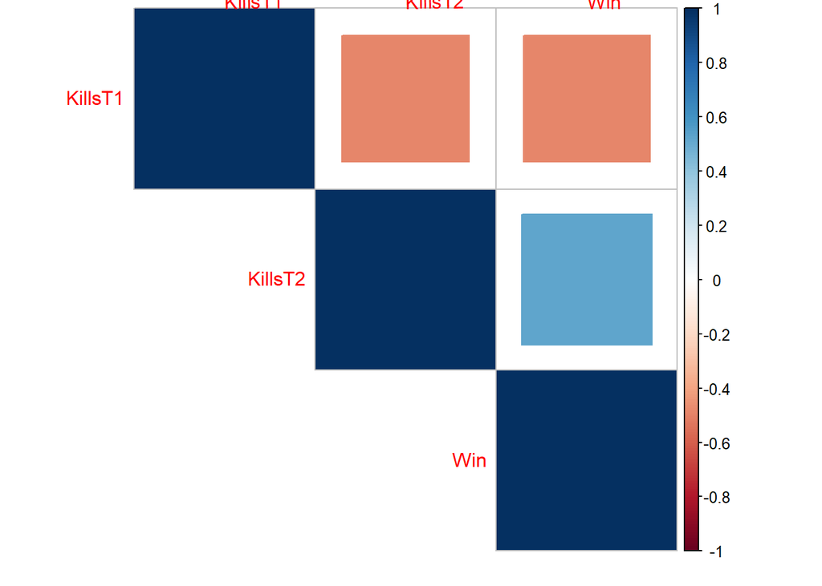

```r
corrplot(res.dragons.win.round, method="square", type = "upper", tl.srt = 0.7)
```

Lo exportamos a PDF para poderlo ver con mayor calidad…

```r
pdf("../imagenes/DrakesCorr.pdf")

corrplot(res.dragons.win.round, method="square", type = "upper", tl.srt = 0.7)

dev.off
```

```
## function (which = dev.cur())
## {
##     if (which == 1)
##         stop("cannot shut down device 1 (the null device)")
##     .External(C_devoff, as.integer(which))
##     dev.cur()
## }
## <bytecode: 0x0000000016564710>
## <environment: namespace:grDevices>
```

Como podemos ver, tenemos una correlación de aproximadamente el 50% entre el aumento del número de dragones matados y conseguir la victoria.

#### Equipo 1

Vamos a ver el número de dragones matados por el equipo 1 respecto a la victoria:

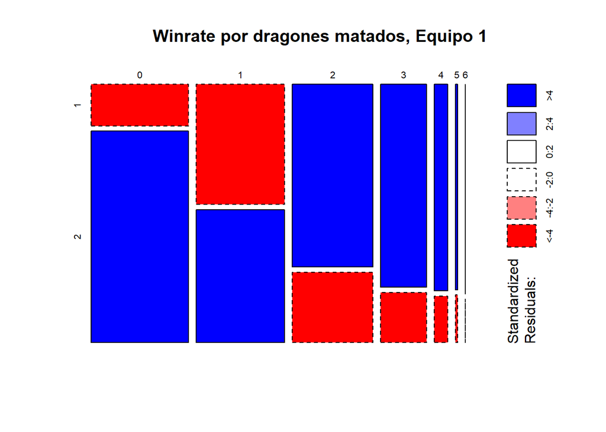

```r
mosaicplot(table(data.dragons.win[, 1], data.dragons.win[, 3]), main='Winrate por dragones matados, Equipo 1', shade=TRUE)
```

Como podemos ver, el equipo 1, si no mata a ningún dragón, tiene serias posibilidades de no ser el equipo que gane. Conforme va matando dragones, aumenta la posibilidad, especialmente con el paso de 1 a 2 dragones, donde se planta con una mayor parte de las posibilidades.

A partir de los 3 dragones matados, el hecho de matar más no tiene prácticamente influencia en el resultado final.

#### Equipo 2

Procedemos igual con el equipo 2:

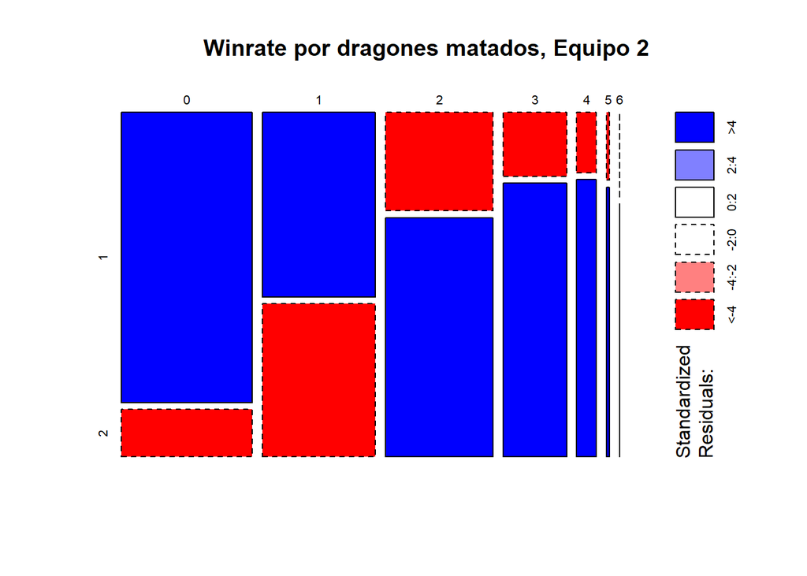

```r
mosaicplot(table(data.dragons.win[, 2], data.dragons.win[, 3]), main='Winrate por dragones matados, Equipo 2', shade=TRUE)
```

Exportamos los MosaicPlot a PDF para tenerlos vectoriales…

```r
pdf("../imagenes/Drakes MosaicPlot.pdf")

mosaicplot(table(data.dragons.win[, 1], data.dragons.win[, 3]), main='Winrate por dragones matados, Equipo 1', shade=TRUE)
mosaicplot(table(data.dragons.win[, 2], data.dragons.win[, 3]), main='Winrate por dragones matados, Equipo 2', shade=TRUE)

dev.off
```

```
## function (which = dev.cur())
## {
##     if (which == 1)
##         stop("cannot shut down device 1 (the null device)")
##     .External(C_devoff, as.integer(which))
##     dev.cur()
## }
## <bytecode: 0x0000000016564710>
## <environment: namespace:grDevices>
```

Como se puede observar, las distribuciones son prácticamente similares, solo que en espejo como es normal.

### ¿Cuales son los campeones más escogidos?

Sabemos que Yasuo es el campeón más baneado, con un 6% de banrate. Ahora me pregunto cual es el campeón más escogido para jugar.

Para ello, tenemos que seguir la misma metodología que en la parte de los baneos:

```r
# Lo que voy a hacer es contar por columnas, y luego sumo todas las columnas que he contado. Así obtengo el recuento final

# TEAM 1

cont.picks.t1.1 <- ddply(data.games,.(t1_champ1id),nrow)
cont.picks.t1.1 <- cont.picks.t1.1[order(cont.picks.t1.1$V1, decreasing = TRUE), ]
cont.picks.t1.2 <- ddply(data.games,.(t1_champ2id),nrow)
cont.picks.t1.2 <- cont.picks.t1.2[order(cont.picks.t1.2$V1, decreasing = TRUE), ]
cont.picks.t1.3 <- ddply(data.games,.(t1_champ3id),nrow)
cont.picks.t1.3 <- cont.picks.t1.3[order(cont.picks.t1.3$V1, decreasing = TRUE), ]
cont.picks.t1.4 <- ddply(data.games,.(t1_champ4id),nrow)
cont.picks.t1.4 <- cont.picks.t1.4[order(cont.picks.t1.4$V1, decreasing = TRUE), ]
cont.picks.t1.5 <- ddply(data.games,.(t1_champ5id),nrow)
cont.picks.t1.5 <- cont.picks.t1.5[order(cont.picks.t1.5$V1, decreasing = TRUE), ]

# TEAM 2

cont.picks.t2.1 <- ddply(data.games,.(t2_champ1id),nrow)
cont.picks.t2.1 <- cont.picks.t2.1[order(cont.picks.t2.1$V1, decreasing = TRUE), ]
cont.picks.t2.2 <- ddply(data.games,.(t2_champ2id),nrow)
cont.picks.t2.2 <- cont.picks.t2.2[order(cont.picks.t2.2$V1, decreasing = TRUE), ]
cont.picks.t2.3 <- ddply(data.games,.(t2_champ3id),nrow)
cont.picks.t2.3 <- cont.picks.t2.3[order(cont.picks.t2.3$V1, decreasing = TRUE), ]
cont.picks.t2.4 <- ddply(data.games,.(t2_champ4id),nrow)
cont.picks.t2.4 <- cont.picks.t2.4[order(cont.picks.t2.4$V1, decreasing = TRUE), ]
cont.picks.t2.5 <- ddply(data.games,.(t2_champ5id),nrow)
cont.picks.t2.5 <- cont.picks.t2.5[order(cont.picks.t2.5$V1, decreasing = TRUE), ]

# Ahora lo que tengo que hacer es sumar todas estas columnas de V1 según el valor de name...

df.picks <- left_join(cont.picks.t1.1, cont.picks.t1.2, by =c("t1_champ1id" = "t1_champ2id"))
df.picks <- left_join(df.picks, cont.picks.t1.3, by =c("t1_champ1id" = "t1_champ3id"))
df.picks <- left_join(df.picks, cont.picks.t1.4, by =c("t1_champ1id" = "t1_champ4id"))
df.picks <- left_join(df.picks, cont.picks.t1.5, by =c("t1_champ1id" = "t1_champ5id"))

df.picks <- left_join(df.picks, cont.picks.t2.1, by =c("t1_champ1id" = "t2_champ1id"))
df.picks <- left_join(df.picks, cont.picks.t2.2, by =c("t1_champ1id" = "t2_champ2id"))
df.picks <- left_join(df.picks, cont.picks.t2.3, by =c("t1_champ1id" = "t2_champ3id"))
df.picks <- left_join(df.picks, cont.picks.t2.4, by =c("t1_champ1id" = "t2_champ4id"))
df.picks <- left_join(df.picks, cont.picks.t2.5, by =c("t1_champ1id" = "t2_champ5id"))

df.picks$total <- rowSums( df.picks[,2:11] )

remove(cont.picks.t1.1)
remove(cont.picks.t1.2)
remove(cont.picks.t1.3)
remove(cont.picks.t1.4)
remove(cont.picks.t1.5)
remove(cont.picks.t2.1)
remove(cont.picks.t2.2)
remove(cont.picks.t2.3)
remove(cont.picks.t2.4)
remove(cont.picks.t2.5)

df.picks <- df.picks[order(df.picks$total, decreasing = TRUE), ]
df.picks <- df.picks[, -2:-11]
head(df.picks)
```

```
##   t1_champ1id total
## 2         412 13002
## 1          18 12983
## 3          67 10658
## 4         141  9853
## 5          64  9188
## 6          29  8838
```

```r
# Finalmente, junto con la tabla de data.champs para ponerles nombre...

df.picks <- left_join(df.picks, data.champs, by=c("t1_champ1id" = "id"))
df.picks <- df.picks[, -1]
head(df.picks)
```

```
##   total     name
## 1 13002   Thresh
## 2 12983 Tristana
## 3 10658    Vayne
## 4  9853     Kayn
## 5  9188  Lee Sin
## 6  8838   Twitch
```

Ahora que tenemos todos los picks contados, es hora de hacer un wordcloud para poder verlo visualmente:

[figure not shown]

```r
set.seed(9998) # Para el mantenimiento del mismo patrón

wordcloud(words = df.picks$name, freq = df.picks$total, min.freq = 3000, random.order=FALSE,
          rot.per=0.5, colors=c("Orange","Purple","Pink", "Red", "Yellow", "Green", "Blue", "Black")
         )
```

```r
# Ratio del más baneado

print("El porcentaje de pick de Thresh es de: ")
```

```
## [1] "El porcentaje de pick de Thresh es de: "
```

```r
ratio.pick.thresh <- df.picks$total[1]/sum(df.picks$total)
print(ratio.pick.thresh)
```

```
## [1] 0.02525151
```

Exporto el Wordcloud a PDF para tenerlo vectorial…

```r
pdf("../imagenes/wordcloudPicks.pdf")

set.seed(9998) # Para el mantenimiento del mismo patrón

wordcloud(words = df.picks$name, freq = df.picks$total, min.freq = 3000, random.order=FALSE,
          rot.per=0.5, colors=c("Orange","Purple","Pink", "Red", "Yellow", "Green", "Blue", "Black")
         )

dev.off
```

```
## function (which = dev.cur())
## {
##     if (which == 1)
##         stop("cannot shut down device 1 (the null device)")
##     .External(C_devoff, as.integer(which))
##     dev.cur()
## }
## <bytecode: 0x0000000016564710>
## <environment: namespace:grDevices>
```

Está muy bien que Thresh y Tristana sean los más elegidos, pero… ¿esto es porque conllevan mayor victoria de partidas? Vamos a calcularlo:

### ¿Qué camepones conllevan un mayor winrate?

Para esto, lo primero que tenemos que hacer es crear un nuevo dataframe con los campeones que han ganado cada partida:

```r
dataframe.winners.1 <- filter(data.games, winner == "1")

# En este dataframe, solo me interesan las columnas de los campeones elegidos por el equipo 1, por lo que solo me quedo con ellas:

dataframe.winners.1 <- dataframe.winners.1[, c(12, 15, 18, 21, 24)]
colnames(dataframe.winners.1) <- c("Pick1", "Pick2", "Pick3", "Pick4", "Pick5")

# Hacemos lo mismo con los ganadores del equipo 2

dataframe.winners.2 <- filter(data.games, winner == "2")

# En este dataframe, solo me interesan las columnas de los campeones elegidos por el equipo 1, por lo que solo me quedo con ellas:

dataframe.winners.2 <- dataframe.winners.2[, c(37, 40, 43, 46, 49)]
colnames(dataframe.winners.2) <- c("Pick1", "Pick2", "Pick3", "Pick4", "Pick5")

# Ahora los juntamos...

dataframe.winners <- rbind(dataframe.winners.1, dataframe.winners.2)

remove(dataframe.winners.1)
remove(dataframe.winners.2)
```

Ahora ya tenemos preparado el dataframe para poder jugar con él. Procedemos contando el número de ocurrencias que hay de cada campeón, y con esto veremos cual es el campeón que más se repite en este dataframe donde solo están las victorias:

```r
# Ahora voy a llevar todas las columnas a una:

dataframe.winners <- data.frame(all = c(dataframe.winners[,"Pick1"],
                                        dataframe.winners[,"Pick2"],
                                        dataframe.winners[,"Pick3"],
                                        dataframe.winners[,"Pick4"],
                                        dataframe.winners[,"Pick5"]))

head(dataframe.winners)
```

```
##   all
## 1   8
## 2 119
## 3  18
## 4  57
## 5  19
## 6  40
```

```r
dataframe.winners <- left_join(dataframe.winners, data.champs, by=c("all" = "id"))

dataframe.winners <- dataframe.winners[, -1]

head(dataframe.winners)
```

```
## [1] Vladimir Draven   Tristana Maokai   Warwick  Janna
## 138 Levels: Aatrox Ahri Akali Alistar Amumu Anivia Annie Ashe Aurelion Sol Azir Bard ... Zyra
```

```r
# Ahora tenemos todo el dataframe en una única columna, donde solo nos queda ordenar y contar el número de ocurrencias:

dataframe.winners <- dataframe.winners[order(dataframe.winners)]
head(dataframe.winners)
```

```
## [1] Aatrox Aatrox Aatrox Aatrox Aatrox Aatrox
## 138 Levels: Aatrox Ahri Akali Alistar Amumu Anivia Annie Ashe Aurelion Sol Azir Bard ... Zyra
```

```r
# Contamos

cantidad <- as.data.frame(table(dataframe.winners))

cantidad <- cantidad[order(cantidad$Freq, decreasing = TRUE), ]
colnames(cantidad) <- c("name", "freq")
head(cantidad)
```

```
##         name freq
## 112 Tristana 6713
## 111   Thresh 6143
## 120    Vayne 5498
## 42     Janna 4826
## 54      Kayn 4807
## 116   Twitch 4665
```

Como podemos ver, los campeones más elegidos son Tristana y Thresh, que casualmente, como acabamos de probar, son los que tienen más victorias en su haber. También, la tercera con más picks es Vayne, y también es la tercera en cantidad de victorias.

Vamos a calcular el ratio pick-victory:

```r
# Para hacer esto, voy a juntar los dos dataframes en uno solo, juntando por el valor del campeón (nombre), y una vez hecho esto podré restar entre mismas columnas

# No puedo hacer un join normal porque todos mis elementos de texto son factors, por eso lo reconvierto

cantidad <- data.frame(cantidad, stringsAsFactors = FALSE)
colnames(cantidad) <- c("name", "freq_win")

df.picks <- data.frame(df.picks, stringsAsFactors = FALSE)
colnames(df.picks) <- c("total_picks", "name")

dataframe.pick.win <- inner_join(cantidad, df.picks, by="name")

# Ahora que tengo los datos a mano, podemos hacer las divisiones:

dataframe.pick.win <- transform(dataframe.pick.win, ratio = dataframe.pick.win[, 2] / dataframe.pick.win[, 3])

dataframe.pick.win <- dataframe.pick.win[order(dataframe.pick.win$ratio, decreasing = TRUE), ]

head(dataframe.pick.win)
```

```
##       name freq_win total_picks     ratio
## 4    Janna     4826        8691 0.5552871
## 29    Sona     2942        5429 0.5419046
## 120 Yorick      744        1378 0.5399129
## 66  Rammus     1614        2997 0.5385385
## 87  Anivia     1207        2252 0.5359680
## 118 Singed      762        1425 0.5347368
```

Es interesante ver que, a la vista de estos resultados, la gente banea lo que ve mucho, no lo que de verdad gana partidas. Como podemos observar, Janna, Sona y Yorick son los 3 campeones que más porcentaje de partidas ganan. En cambio, a la hora de escogerlos los vemos en las posiciones 7, 30 y 124. Respecto a bans, si tantas partidas ganan la masa debería de banearlos, pero se encuentran en las posiciones 5, 91 y 96, por lo que la gente no se da cuenta del peligro de estos campeones en las manos adecuadas.

### ¿El lado rojo (equipo 2) pierde más partidas?

Una de las afirmaciones que corre por la comunidad de League of Legends es la creencia de que el lado rojo, correspondiente con el equipo 2 en nuestro dataset, es el que pierde un mayor número de partidas. Para visualizar esto, lo único que hay que hacer es obtener el winrate del equipo rojo respecto al total de partidas:

```r
columna.wins <- data.games$winner
cantidad.wins <- as.data.frame(table(columna.wins))
colnames(cantidad.wins) <- c("winner", "frequency")
head(cantidad.wins)
```

```
##   winner frequency
## 1      1     26077
## 2      2     25413
```

```r
# Si calculamos el ratio...

ratio.red <- cantidad.wins[2, 2] / (cantidad.wins[1, 2] + cantidad.wins[2, 2])
ratio.red
```

```
## [1] 0.4935521
```

```r
ratio.blue <- cantidad.wins[1, 2] / (cantidad.wins[1, 2] + cantidad.wins[2, 2])
ratio.blue
```

```
## [1] 0.5064479
```

Es decir, el grupo que juega en el lado rojo gana el 49,35% de las partidas, mientras que el que juega en el lado azul gana el 50,64%.

Vamos a verlo en forma de gráfica:

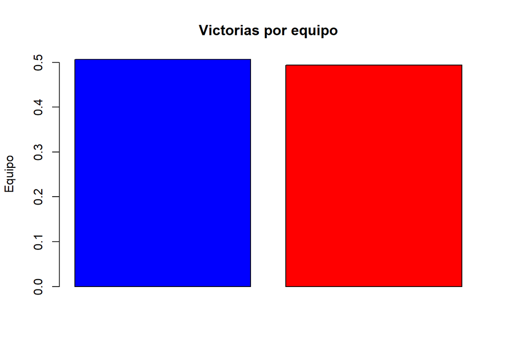

```r
ratios_win <- c(ratio.blue, ratio.red)
barplot(ratios_win, main="Victorias por equipo", ylab="Equipo", col = c("Blue", "Red"))
```

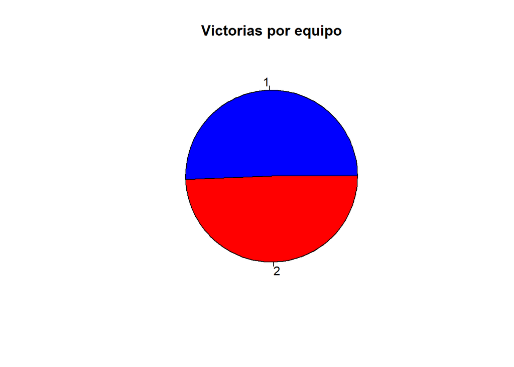

```r
pie(table(data.games$winner), main = "Victorias por equipo", col = c("Blue", "Red"))
```

Lo exportamos a PDF…

```r
pdf("../imagenes/Winrate Graphs.pdf")
barplot(ratios_win, main="Victorias por equipo", ylab="Equipo", col = c("Blue", "Red"))
pie(table(data.games$winner), main = "Victorias por equipo", col = c("Blue", "Red"))
dev.off
```

```
## function (which = dev.cur())
## {
##     if (which == 1)
##         stop("cannot shut down device 1 (the null device)")
##     .External(C_devoff, as.integer(which))
##     dev.cur()
## }
## <bytecode: 0x0000000016564710>
## <environment: namespace:grDevices>
```

### ¿Quién consigue más primeros objetivos?

Los primeros objetivos son cruciales en la partida, ya que algunos dan extra de oro, pero todos empiezan a decantar la partida a tu favor. Debido a ello, el análisis de si existe alguna diferencia entre los equipos a la hora de conseguir los primeros objetivos se plantea crucial.

Para ello, contaré para cada columna de primeros objetivos qué equipo ha conseguido ser el mejor, y por qué porcentaje, y entonces determinaré si hay alguna ventaja en alguno de los objetivos.

```r
# Los datos de esto los tenemos en data.games. Para aclarar, vamos a hacer un dataset específico con los datos de los objetivos...

data.first.objectives <- data.games[, 6:11]

# Es importante remarcar que aquí hay 3 valores: 0 si nadie lo ha conseguido, 1 si lo ha conseguido el equipo azul y 2 si lo ha conseguido el equipo rojo.

head(data.first.objectives)
```

```
##   firstBlood firstTower firstInhibitor firstBaron firstDragon firstRiftHerald
## 1          2          1              1          1           1               2
## 2          1          1              1          0           1               1
## 3          2          1              1          1           2               0
## 4          1          1              1          1           1               0
## 5          2          1              1          1           1               0
## 6          2          2              1          1           2               0
```

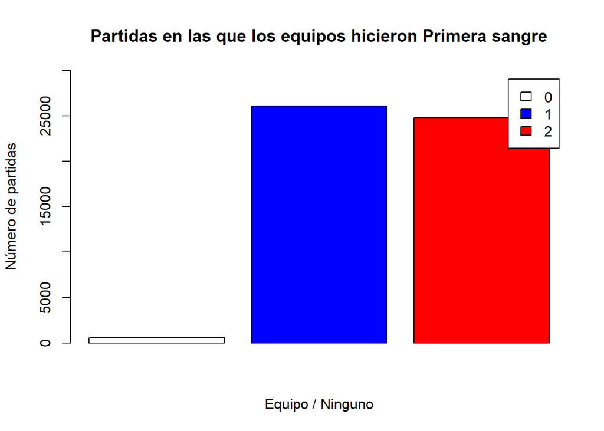

```r
# Ahora mi objetivo es contar de cada una de las líneas lo que hay, y de aquí sacar conclusiones:

firstblood.qty <- as.data.frame(table(data.first.objectives[, 1]))
firsttower.qty <- as.data.frame(table(data.first.objectives[, 2]))
firstinhib.qty <- as.data.frame(table(data.first.objectives[, 3]))
firstbaron.qty <- as.data.frame(table(data.first.objectives[, 4]))
firstdragon.qty <- as.data.frame(table(data.first.objectives[, 5]))
firstherald.qty <- as.data.frame(table(data.first.objectives[, 6]))

# Ahora lo vemos bien en barplots...

array.firstblood <- c(firstblood.qty[1, 2],firstblood.qty[2, 2], firstblood.qty[3, 2])
barplot(array.firstblood, main="Partidas en las que los equipos hicieron Primera sangre", xlab="Equipo / Ninguno", ylab = "Número de partidas",
        ylim = c(0,30000), col = c("White", "Blue", "Red"), legend.text=firstblood.qty$Var1)
```

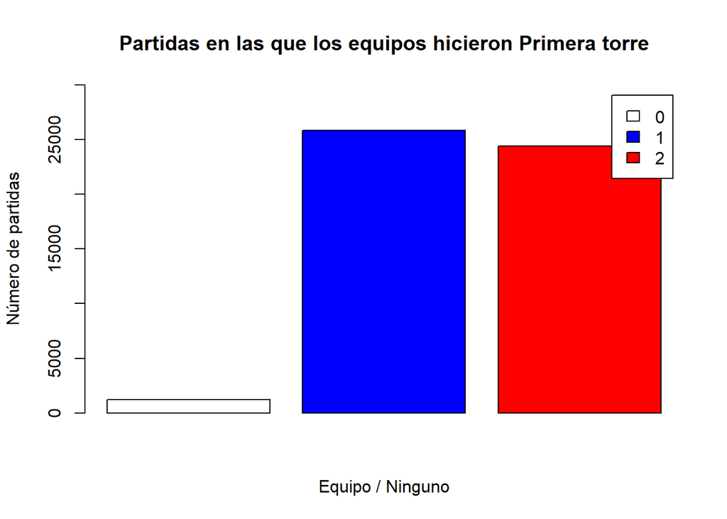

```r
array.firsttower <- c(firsttower.qty[1, 2],firsttower.qty[2, 2], firsttower.qty[3, 2])
barplot(array.firsttower, main="Partidas en las que los equipos hicieron Primera torre", xlab="Equipo / Ninguno", ylab = "Número de partidas",
        ylim = c(0,30000), col = c("White", "Blue", "Red"), legend.text=firsttower.qty$Var1)
```

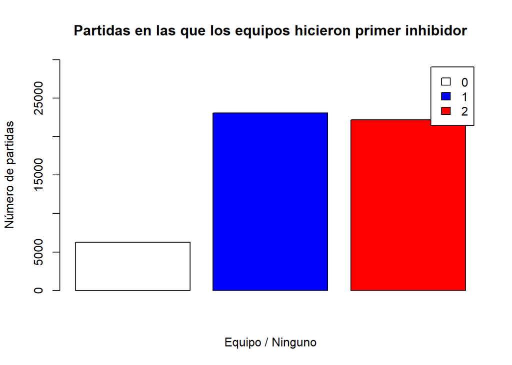

```r
array.firstinhib <- c(firstinhib.qty[1, 2],firstinhib.qty[2, 2], firstinhib.qty[3, 2])
barplot(array.firstinhib, main="Partidas en las que los equipos hicieron primer inhibidor", xlab="Equipo / Ninguno", ylab = "Número de partidas",
        ylim = c(0,30000), col = c("White", "Blue", "Red"), legend.text=firstinhib.qty$Var1)
```

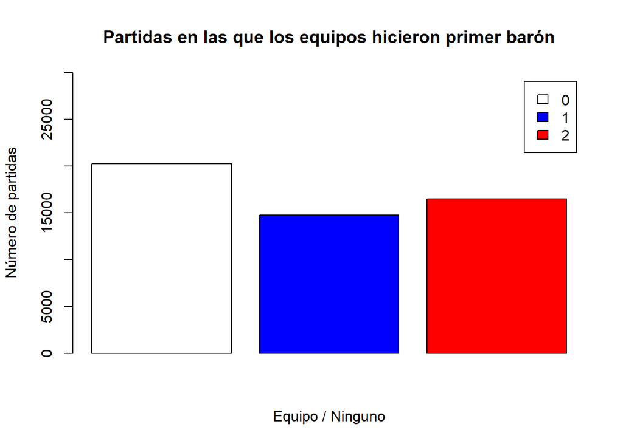

```r
array.firstbaron <- c(firstbaron.qty[1, 2],firstbaron.qty[2, 2], firstbaron.qty[3, 2])
barplot(array.firstbaron, main="Partidas en las que los equipos hicieron primer barón", xlab="Equipo / Ninguno", ylab = "Número de partidas",
        ylim = c(0,30000), col = c("White", "Blue", "Red"), legend.text=firstbaron.qty$Var1)
```

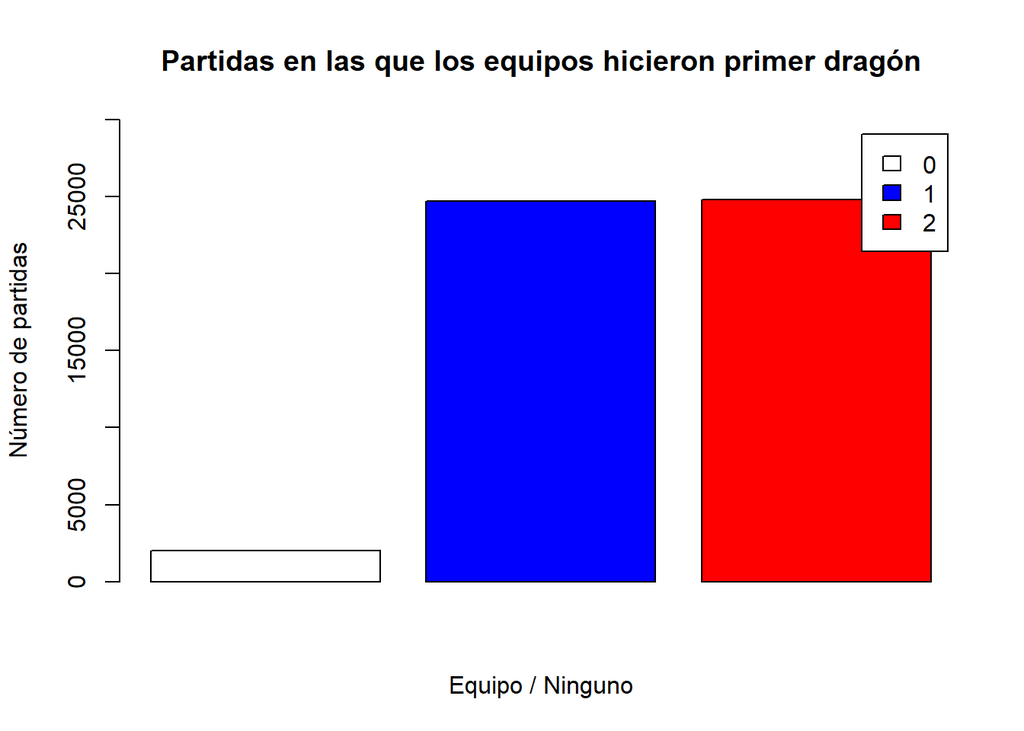

```r
array.firstdragon <- c(firstdragon.qty[1, 2],firstdragon.qty[2, 2], firstdragon.qty[3, 2])
barplot(array.firstdragon, main="Partidas en las que los equipos hicieron primer dragón", xlab="Equipo / Ninguno", ylab = "Número de partidas",
        ylim = c(0,30000), col = c("White", "Blue", "Red"), legend.text=firstdragon.qty$Var1)
```

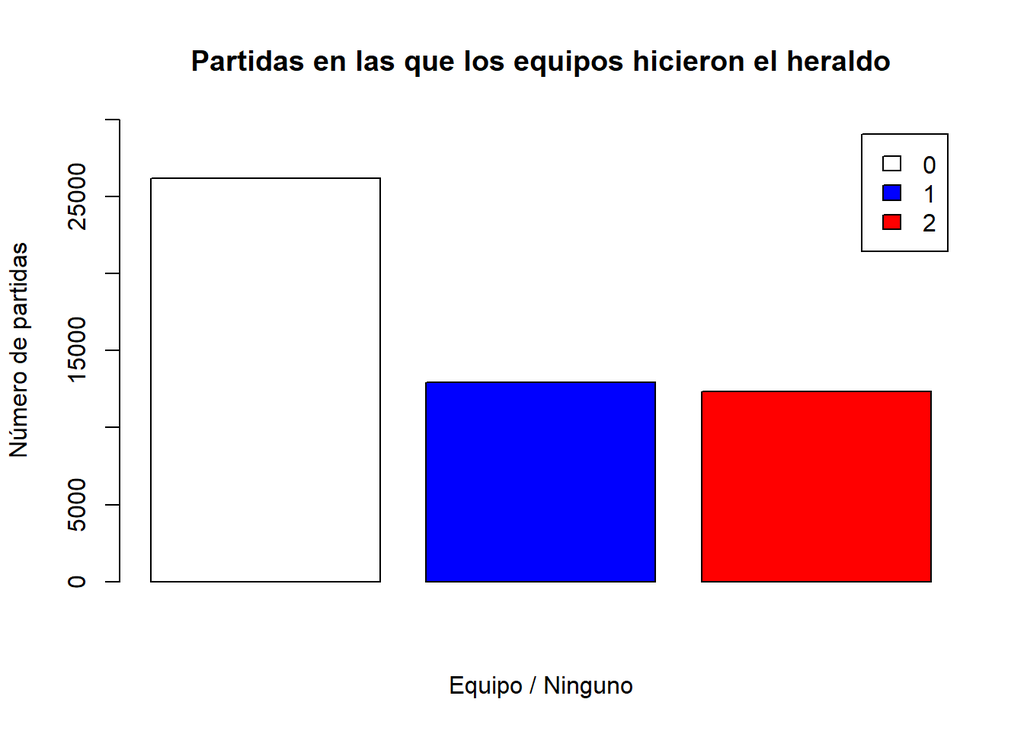

```r
array.firstherald <- c(firstherald.qty[1, 2],firstherald.qty[2, 2], firstherald.qty[3, 2])
barplot(array.firstherald, main="Partidas en las que los equipos hicieron el heraldo", xlab="Equipo / Ninguno", ylab = "Número de partidas",
        ylim = c(0,30000), col = c("White", "Blue", "Red"), legend.text=firstherald.qty$Var1)
```

Si ponemos todos estos en orden cronológico a cuando suelen pasar, obtenemos lo siguiente:

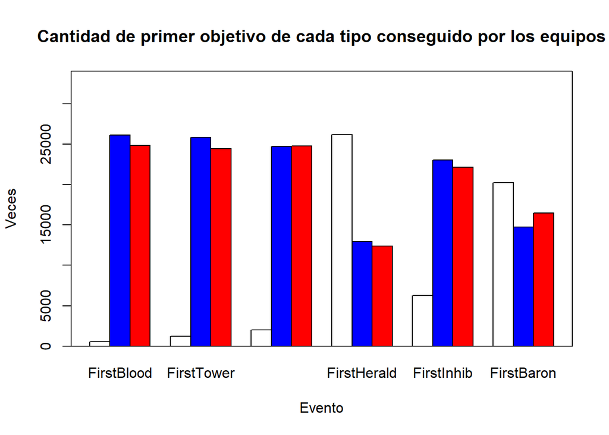

```r
dataframe.firstObjective <- cbind(array.firstblood, array.firsttower, array.firstdragon, array.firstherald, array.firstinhib, array.firstbaron)
colnames(dataframe.firstObjective) <- c('FirstBlood', 'FirstTower', 'FirstDragon', 'FirstHerald', 'FirstInhib', 'FirstBaron')

colours = c("white","blue","red")

barplot(dataframe.firstObjective, main='Cantidad de primer objetivo de cada tipo conseguido por los equipos',ylab='Veces', xlab='Evento',beside = TRUE,
        col=colours, ylim=c(0,max(dataframe.firstObjective)*1.3))

box()
```

Exportamos a PDF este gráfico…

```r
pdf("../imagenes/Barplot Cronología Partida FO.pdf")

barplot(dataframe.firstObjective, main='Cantidad de primer objetivo de cada tipo conseguido por los equipos',ylab='Veces', xlab='Evento',beside = TRUE,
        col=colours, ylim=c(0,max(dataframe.firstObjective)*1.3))

box()

dev.off
```

```
## function (which = dev.cur())
## {
##     if (which == 1)
##         stop("cannot shut down device 1 (the null device)")
##     .External(C_devoff, as.integer(which))
##     dev.cur()
## }
## <bytecode: 0x0000000016564710>
## <environment: namespace:grDevices>
```

Como podemos ver en los gráficos, la primera sangre y primera torre suelen caer un poco más del lado del equipo azul, siendo estos elementos que se dan al principio de la partida.

Respecto al primer dragón y el heraldo, que se dan en el medio de la partida, se igualan las tornas.

Sin embargo, con los objetivos de final de partida, como es el primer barón, es el equipo rojo quien lo suele conseguir. En cambio, el equipo azul suele conseguir con un poco más de frecuencia el primer inhibidor.

## Machine Learning

### Preparación datos machine learning

#### Dataset total

Ahora usaremos algoritmos de Machine Learning para ver si somos capaces de predecir quién va a ganar en base a una serie de características.

Para hacer esto, vamos a crear un dataset a partir de data.games solo para lo que va a ser el Machine Learning. En él, dejaré las variables que creo necesarias para la predicción de una partida y así usaremos este dataset, tras un centrado y escalado.

Creación del Dataset:

```r
data.games.names <- inner_join(data.games, data.champs, by = c("t1_champ1id" = "id"))
data.games.names <- inner_join(data.games.names, data.champs, by = c("t1_champ2id" = "id"))
data.games.names <- inner_join(data.games.names, data.champs, by = c("t1_champ3id" = "id"))
data.games.names <- inner_join(data.games.names, data.champs, by = c("t1_champ4id" = "id"))
data.games.names <- inner_join(data.games.names, data.champs, by = c("t1_champ5id" = "id"))
data.games.names <- inner_join(data.games.names, data.champs, by = c("t2_champ1id" = "id"))
data.games.names <- inner_join(data.games.names, data.champs, by = c("t2_champ2id" = "id"))
data.games.names <- inner_join(data.games.names, data.champs, by = c("t2_champ3id" = "id"))
data.games.names <- inner_join(data.games.names, data.champs, by = c("t2_champ4id" = "id"))
data.games.names <- inner_join(data.games.names, data.champs, by = c("t2_champ5id" = "id"))

champs.names <- data.games.names[,62:71]
colnames(champs.names) <- c("P1T1", "P2T1", "P3T1", "P4T1", "P5T1", "P1T2", "P2T2", "P3T2", "P4T2", "P5T2")


# Ahora paso todos los campeones a variables binarias. Esto hace que para todas las predicciones no tenga que usar distancias ni categorías entre ellos, lo que me permite que sean más justas.

vectors_champs <- dummy_cols(champs.names)
vectors_champs <- vectors_champs[, -1:-10]

# Ahora lo único que tengo que hacer es crear el dataset final para el machine learning, quitando aquellas variables que no deseo que estén (entre ellas el código de los campeones) y añadiendo esta codificación binaria que acabo de crear.

data.ml <- data.games[, c(-1, -2, -4, -13, -14, -16, -17, -19, -20, -22, -23, -25, -26, -38, -39, -41, -42, -44, -45, -47, -48)]
data.ml <- data.ml[, -9:-13]
data.ml <- data.ml[, -19:-25]

# Ahora hago lo mismo de antes para los nombres pero con los bans. Antes que nada, tengo que añadir None como la elección de ningún campeón para banear en el df de campeones.

df.tonto <- data.frame("None", as.integer(1000))
names(df.tonto) <- c("name", "id")
data.champs <- rbind(data.champs, df.tonto)

data.games[data.games=="-1"]<-1000

data.games.bans <- inner_join(data.games, data.champs, by = c("t1_ban1" = "id"))
data.games.bans <- inner_join(data.games.bans, data.champs, by = c("t1_ban2" = "id"))
data.games.bans <- inner_join(data.games.bans, data.champs, by = c("t1_ban3" = "id"))
data.games.bans <- inner_join(data.games.bans, data.champs, by = c("t1_ban4" = "id"))
data.games.bans <- inner_join(data.games.bans, data.champs, by = c("t1_ban5" = "id"))
data.games.bans <- inner_join(data.games.bans, data.champs, by = c("t2_ban1" = "id"))
data.games.bans <- inner_join(data.games.bans, data.champs, by = c("t2_ban2" = "id"))
data.games.bans <- inner_join(data.games.bans, data.champs, by = c("t2_ban3" = "id"))
data.games.bans <- inner_join(data.games.bans, data.champs, by = c("t2_ban4" = "id"))
data.games.bans <- inner_join(data.games.bans, data.champs, by = c("t2_ban5" = "id"))

champs.bans.names <- data.games.bans[,62:71]
colnames(champs.bans.names) <- c("B1T1", "B2T1", "B3T1", "B4T1", "B5T1", "B1T2", "B2T2", "B3T2", "B4T2", "B5T2")


vectors_champs.bans <- dummy_cols(champs.bans.names)
vectors_champs.bans <- vectors_champs.bans[, -1:-10]

# Finalmente, hago las últimas transformaciones y adiciones a data.ml para obtener el resultado final

data.ml <- data.ml[, -14:-18]
data.ml <- data.ml[, -19:-23]

data.ml <- cbind(data.ml, vectors_champs, vectors_champs.bans)

# Finalmente,hago una segunda matriz sin el resultado, que será la que centre y escale:

data.ml.centscal <- data.ml[, -2]
```

Ahora hacemos un centrado y escalado de los datos para evitar distorsionar la predicción:

```r
preObjeto <- preProcess(data.ml.centscal, method=c("center", "scale"))  # Quiero hacer un centrado y escalado
data.ml.centscal <- predict(preObjeto, data.ml.centscal)
```

Estos archivos son grandes, veamos su tamaño:

```r
object_size(data.ml)
```

```
## 575 MB
```

```r
object_size(data.ml.centscal)
```

```
## 1.15 GB
```

```r
resultado.pca.ml <- PCA(data.ml.centscal, graph = FALSE)

#Con la siguiente línea podemos ver que podemos hacer con esto calculado
print(resultado.pca.ml)
```

```
## **Results for the Principal Component Analysis (PCA)**
## The analysis was performed on 51490 individuals, described by 2787 variables
## *The results are available in the following objects:
##
##    name               description
## 1  "$eig"             "eigenvalues"
## 2  "$var"             "results for the variables"
## 3  "$var$coord"       "coord. for the variables"
## 4  "$var$cor"         "correlations variables - dimensions"
## 5  "$var$cos2"        "cos2 for the variables"
## 6  "$var$contrib"     "contributions of the variables"
## 7  "$ind"             "results for the individuals"
## 8  "$ind$coord"       "coord. for the individuals"
## 9  "$ind$cos2"        "cos2 for the individuals"
## 10 "$ind$contrib"     "contributions of the individuals"
## 11 "$call"            "summary statistics"
## 12 "$call$centre"     "mean of the variables"
## 13 "$call$ecart.type" "standard error of the variables"
## 14 "$call$row.w"      "weights for the individuals"
## 15 "$call$col.w"      "weights for the variables"
```

Nos interesa ver los eigenvalues, que son los que presentarán la cantidad de varianza que aportan las variables:

```r
eigenvalues.PCA.ml <- resultado.pca.ml$eig
head(eigenvalues.PCA.ml)
```

```
##        eigenvalue percentage of variance cumulative percentage of variance
## comp 1   5.508868             0.19766300                         0.1976630
## comp 2   3.274071             0.11747655                         0.3151395
## comp 3   3.015903             0.10821324                         0.4233528
## comp 4   1.994136             0.07155134                         0.4949041
## comp 5   1.877788             0.06737667                         0.5622808
## comp 6   1.833950             0.06580373                         0.6280845
```

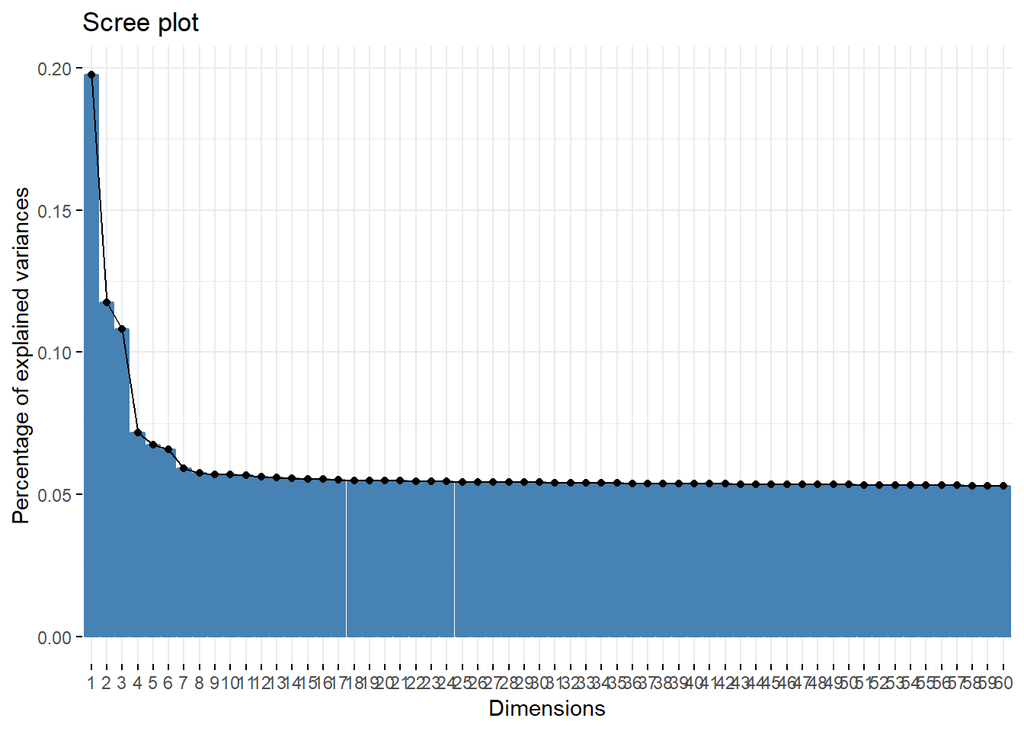

```r
plotPCA.ml <- fviz_screeplot(resultado.pca.ml, ncp=60)
plot(plotPCA.ml)
```

Exportamos a PDF…

```r
pdf("../imagenes/PCATotal.pdf")
plot(plotPCA.ml)
dev.off
```

```
## function (which = dev.cur())
## {
##     if (which == 1)
##         stop("cannot shut down device 1 (the null device)")
##     .External(C_devoff, as.integer(which))
##     dev.cur()
## }
## <bytecode: 0x0000000016564710>
## <environment: namespace:grDevices>
```

Como vemos, todas las dimensiones van aportando su “granito de arena”, pero ninguna de ellas (según estamos viendo en las 60 primeras) deja de aportar un poco.

Si vamos al dataframe generado en eigenvalues.PCA.ml, vemos que hasta que no llegamos a las 2000 componentes principales no obtenemos al menos un 80% de explicación, mientras que hasta que no llegamos a unas pocas dimensiones del final no obtenemos la explicación completa. Por ello, no reduciré las dimensiones del dataframe, y trabajaremos con él a pesar de que sea más lento y pesado.

#### Dataset campeones

A partir del dataset total, voy a hacer un dataset solo con los campeones (ya codificados), de tal manera que se pueda predecir también solo por ellos:

```r
data.ml.campeones <- data.ml[, 19:2788]

#matriz.sparse.campeones <- Matrix(data.ml.campeones, sparse = T)
```

Ahora, al igual que antes, calculamos el PCA:

```r
resultado.pca.campeones.ml <- PCA(data.ml.campeones, graph = FALSE)

#Con la siguiente línea podemos ver que podemos hacer con esto calculado
print(resultado.pca.campeones.ml)
```

```
## **Results for the Principal Component Analysis (PCA)**
## The analysis was performed on 51490 individuals, described by 2770 variables
## *The results are available in the following objects:
##
##    name               description
## 1  "$eig"             "eigenvalues"
## 2  "$var"             "results for the variables"
## 3  "$var$coord"       "coord. for the variables"
## 4  "$var$cor"         "correlations variables - dimensions"
## 5  "$var$cos2"        "cos2 for the variables"
## 6  "$var$contrib"     "contributions of the variables"
## 7  "$ind"             "results for the individuals"
## 8  "$ind$coord"       "coord. for the individuals"
## 9  "$ind$cos2"        "cos2 for the individuals"
## 10 "$ind$contrib"     "contributions of the individuals"
## 11 "$call"            "summary statistics"
## 12 "$call$centre"     "mean of the variables"
## 13 "$call$ecart.type" "standard error of the variables"
## 14 "$call$row.w"      "weights for the individuals"
## 15 "$call$col.w"      "weights for the variables"
```

Nos interesa ver los eigenvalues, que son los que presentarán la cantidad de varianza que aportan las variables:

```r
eigenvalues.PCA.campeones.ml <- resultado.pca.campeones.ml$eig
head(eigenvalues.PCA.campeones.ml)
```

```
##        eigenvalue percentage of variance cumulative percentage of variance
## comp 1   3.181314             0.11484890                         0.1148489
## comp 2   1.947903             0.07032139                         0.1851703
## comp 3   1.839567             0.06641037                         0.2515807
## comp 4   1.643525             0.05933303                         0.3109137
## comp 5   1.598470             0.05770651                         0.3686202
## comp 6   1.585067             0.05722264                         0.4258428
```

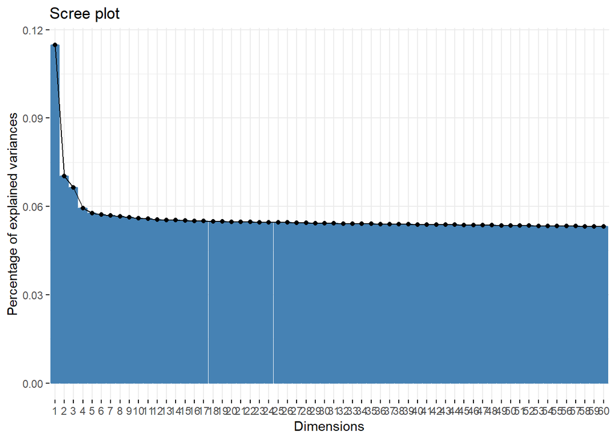

```r
plotPCA.campeones.ml <- fviz_screeplot(resultado.pca.campeones.ml, ncp=60)
plot(plotPCA.campeones.ml)
```

Exportamos a PDF…

```r
pdf("../imagenes/PCACampones.pdf")
plot(plotPCA.campeones.ml)
dev.off
```

```
## function (which = dev.cur())
## {
##     if (which == 1)
##         stop("cannot shut down device 1 (the null device)")
##     .External(C_devoff, as.integer(which))
##     dev.cur()
## }
## <bytecode: 0x0000000016564710>
## <environment: namespace:grDevices>
```

#### Dataset datos equipos

A partir del dataset total, voy a hacer un dataset solo con las estadísticas de los equipos, de tal manera que se pueda predecir también solo por ellos, creando un dataset más pequeño. Con este dataset corroboraremos que no hacen falta los campeones para predecir el ganador de una partida, sino que con las estadísticas vale:

```r
data.ml.stats.centscal <- data.ml[, 1:18]
data.ml.stats.centscal <- data.ml.stats.centscal[, -2] #Quitamos el ganador

preObjeto.stats <- preProcess(data.ml.stats.centscal, method=c("center", "scale"))  # Quiero hacer un centrado y escalado
data.ml.stats.centscal <- predict(preObjeto.stats, data.ml.stats.centscal)
```

Ahora, al igual que antes, calculamos el PCA:

```r
resultado.pca.stats.ml <- PCA(data.ml.stats.centscal, graph = FALSE)

#Con la siguiente línea podemos ver que podemos hacer con esto calculado
print(resultado.pca.stats.ml)
```

```
## **Results for the Principal Component Analysis (PCA)**
## The analysis was performed on 51490 individuals, described by 17 variables
## *The results are available in the following objects:
##
##    name               description
## 1  "$eig"             "eigenvalues"
## 2  "$var"             "results for the variables"
## 3  "$var$coord"       "coord. for the variables"
## 4  "$var$cor"         "correlations variables - dimensions"
## 5  "$var$cos2"        "cos2 for the variables"
## 6  "$var$contrib"     "contributions of the variables"
## 7  "$ind"             "results for the individuals"
## 8  "$ind$coord"       "coord. for the individuals"
## 9  "$ind$cos2"        "cos2 for the individuals"
## 10 "$ind$contrib"     "contributions of the individuals"
## 11 "$call"            "summary statistics"
## 12 "$call$centre"     "mean of the variables"
## 13 "$call$ecart.type" "standard error of the variables"
## 14 "$call$row.w"      "weights for the individuals"
## 15 "$call$col.w"      "weights for the variables"
```

Nos interesa ver los eigenvalues, que son los que presentarán la cantidad de varianza que aportan las variables:

```r
eigenvalues.PCA.stats.ml <- resultado.pca.stats.ml$eig
head(eigenvalues.PCA.stats.ml)
```

```
##        eigenvalue percentage of variance cumulative percentage of variance
## comp 1  5.4055231              31.797194                          31.79719
## comp 2  2.9381181              17.283047                          49.08024
## comp 3  1.7478086              10.281227                          59.36147
## comp 4  1.3032125               7.665956                          67.02743
## comp 5  1.0609948               6.241146                          73.26857
## comp 6  0.9598527               5.646193                          78.91476
```

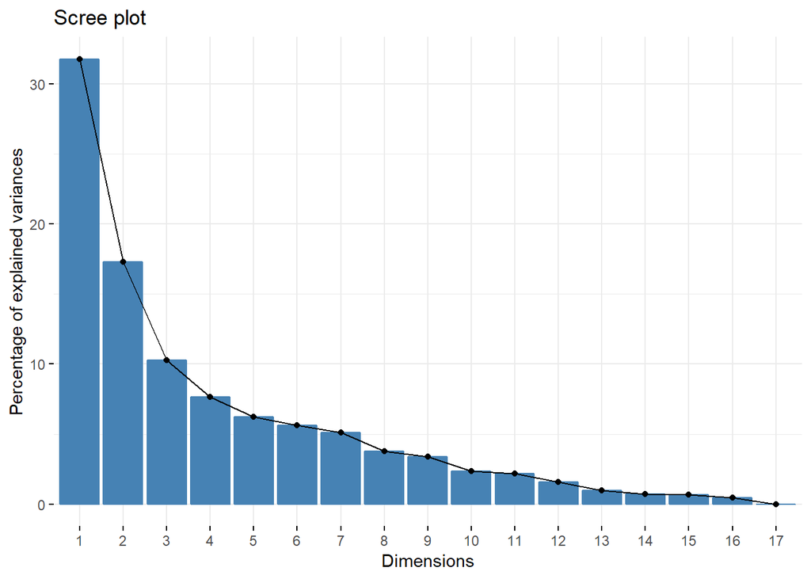

```r
plotPCA.stats.ml <- fviz_screeplot(resultado.pca.stats.ml, ncp=60)
plot(plotPCA.stats.ml)
```

Exportamos a PDF:

```r
pdf("../imagenes/PCAstatsML.pdf")
plot(plotPCA.stats.ml)
dev.off
```

```
## function (which = dev.cur())
## {
##     if (which == 1)
##         stop("cannot shut down device 1 (the null device)")
##     .External(C_devoff, as.integer(which))
##     dev.cur()
## }
## <bytecode: 0x0000000016564710>
## <environment: namespace:grDevices>
```

### Algoritmos Supervisados

Pasamos ahora a una revisión / uso de algoritmos supervisados:

#### Perceptrón Multicapa

El algoritmo supervisado por el que siempre se debe de empezar es el perceptrón multicapa. Con este algoritmo de clasificación voy a intentar predecir el resultado de la partida. Este algoritmo se basa en una red neuronal con una capa intermedia (en este caso), mediante la cual podemos procesar datos más complejos que con un perceptrón monocapa. Con este algoritmo comprobaremos si las partidas ganadas por unos y por otros son linealmente separables.

Ahora vamos a importar la librería nnet, que nos sirve para hacer perceptrones

Ahora lo que hago es coger un conjunto muy grande de los datos para hacer el entrenamiento

```r
conjuntoEntrenamiento <- sample(1:nrow(data.ml.stats.centscal), 45000)
```

Creo una tabla para guardar los resultados de todos los tests del perceptrón:

```r
resultados.perceptron <- data.frame(stringsAsFactors=FALSE)
```

1 NEURONA #################################################### ###############################################################

Lo que voy a hacer ahora es entrenar la red neuronal con diferente cantidad de neuronas,y voy a ir comparando el resultado…

SIN SOFTMAX #############################

```r
# Ahora creamos un dataframe para guardar los resultados de este bucle

  dataframe.resultados.1neu <- data.frame(Ent_1neu=numeric(),
                                          Test_1neu=numeric())


for (i in 1:10)
{

  partidas.1neu <- nnet( data.ml.stats.centscal[conjuntoEntrenamiento, ], class.ind( data.ml[conjuntoEntrenamiento, 2] ) , size=1, MaxNWts=10000 )

  #Una vez que lo tengo entrenado, lo que voy a hacer es calcular el error tanto en el entrenamiento como en el test de cada uno

  partidas.prediccion.1neu <- predict( partidas.1neu, data.ml.stats.centscal[conjuntoEntrenamiento, ], type="raw" )
  head(partidas.prediccion.1neu) # Vemos las probabilidades de pertenencia de cada valor

  # Ahora que los tengo todos entrenados, Determinamos cual es la máxima, es decir, la clase a la que hay que asignar los objetos

  partidas.prediccion.1neu.class <- apply( partidas.prediccion.1neu, MARGIN=1, FUN='which.is.max')

  #Calculo el acierto

  acierto_ent_1neu<- sum( diag( table( partidas.prediccion.1neu.class, data.ml[conjuntoEntrenamiento, 2] ) ) )/length(conjuntoEntrenamiento)

  ###### TEST


  partidas.prediccion.test.1neu <- predict( partidas.1neu, data.ml.stats.centscal[-conjuntoEntrenamiento, ], type="raw" )

  partidas.prediccion.test.1neu.class <- apply( partidas.prediccion.test.1neu, MARGIN=1, FUN='which.is.max')

  table( partidas.prediccion.test.1neu.class , data.ml[-conjuntoEntrenamiento, 2] )

  acierto_test_1neu <- sum( diag( table( partidas.prediccion.test.1neu.class, data.ml[-conjuntoEntrenamiento, 2] ) ) )/(nrow(data.ml.stats.centscal) - length(conjuntoEntrenamiento))


  dataframe.pasada <- data.frame(Ent_1neu = acierto_ent_1neu,
                                 Test_1neu= acierto_test_1neu)

  dataframe.resultados.1neu <- rbind(dataframe.resultados.1neu, dataframe.pasada)

}
```

Ahora le vamos a añadir softmax, a ver si mejoramos…

CON SOFTMAX #############################

```r
  dataframe.resultados.1neu.soft <- data.frame(Ent_1neu_soft=numeric(),
                                               Test_1neu_soft=numeric())

for (i in 1:10)
{

  partidas.1neu.soft <- nnet( data.ml.stats.centscal[conjuntoEntrenamiento, ], class.ind( data.ml[conjuntoEntrenamiento, 2] ) , size=1, MaxNWts=10000, softmax = T )

  #Una vez que lo tengo entrenado, lo que voy a hacer es calcular el error tanto en el entrenamiento como en el test de cada uno

  partidas.prediccion.1neu.soft <- predict( partidas.1neu.soft, data.ml.stats.centscal[conjuntoEntrenamiento, ], type="raw" )
  head(partidas.prediccion.1neu.soft) # Vemos las probabilidades de pertenencia de cada valor

  # Ahora que los tengo todos entrenados, Determinamos cual es la máxima, es decir, la clase a la que hay que asignar los objetos

  partidas.prediccion.1neu.class.soft <- apply( partidas.prediccion.1neu.soft, MARGIN=1, FUN='which.is.max')

  #Calculo el acierto

  acierto_ent_1neu.soft <- sum( diag( table( partidas.prediccion.1neu.class.soft, data.ml[conjuntoEntrenamiento, 2] ) ) )/length(conjuntoEntrenamiento)

  ###### TEST


  partidas.prediccion.test.1neu.soft <- predict( partidas.1neu.soft, data.ml.stats.centscal[-conjuntoEntrenamiento, ], type="raw" )

  partidas.prediccion.test.1neu.class.soft <- apply( partidas.prediccion.test.1neu.soft, MARGIN=1, FUN='which.is.max')

  table( partidas.prediccion.test.1neu.class.soft , data.ml[-conjuntoEntrenamiento, 2] )

  acierto_test_1neu.soft <- sum( diag( table( partidas.prediccion.test.1neu.class.soft, data.ml[-conjuntoEntrenamiento, 2] ) ) )/(nrow(data.ml.stats.centscal) - length(conjuntoEntrenamiento))


  dataframe.pasada <- data.frame(Ent_1neu_soft = acierto_ent_1neu.soft,
                                 Test_1neu_soft= acierto_test_1neu.soft)

  dataframe.resultados.1neu.soft <- rbind(dataframe.resultados.1neu.soft, dataframe.pasada)

}
```

2 NEURONAS ################################################### ###############################################################

SIN SOFTMAX #############################

```r
dataframe.resultados.2neu <- data.frame(Ent_2neu=numeric(),
                                        Test_2neu=numeric())


for (i in 1:10)
{

  partidas.2neu <- nnet( data.ml.stats.centscal[conjuntoEntrenamiento, ], class.ind( data.ml[conjuntoEntrenamiento, 2] ) , size=2, MaxNWts=10000 )

  #Una vez que lo tengo entrenado, lo que voy a hacer es calcular el error tanto en el entrenamiento como en el test de cada uno

  partidas.prediccion.2neu <- predict( partidas.2neu, data.ml.stats.centscal[conjuntoEntrenamiento, ], type="raw" )
  head(partidas.prediccion.2neu) # Vemos las probabilidades de pertenencia de cada valor

  # Ahora que los tengo todos entrenados, Determinamos cual es la máxima, es decir, la clase a la que hay que asignar los objetos

  partidas.prediccion.2neu.class <- apply( partidas.prediccion.2neu, MARGIN=1, FUN='which.is.max')

  #Calculo el acierto

  acierto_ent_2neu<- sum( diag( table( partidas.prediccion.2neu.class, data.ml[conjuntoEntrenamiento, 2] ) ) )/length(conjuntoEntrenamiento)

  ###### TEST


  partidas.prediccion.test.2neu <- predict( partidas.2neu, data.ml.stats.centscal[-conjuntoEntrenamiento, ], type="raw" )

  partidas.prediccion.test.2neu.class <- apply( partidas.prediccion.test.2neu, MARGIN=1, FUN='which.is.max')

  table( partidas.prediccion.test.2neu.class , data.ml[-conjuntoEntrenamiento, 2] )

  acierto_test_2neu <- sum( diag( table( partidas.prediccion.test.2neu.class, data.ml[-conjuntoEntrenamiento, 2] ) ) )/(nrow(data.ml.stats.centscal) - length(conjuntoEntrenamiento))


  dataframe.pasada <- data.frame(Ent_2neu = acierto_ent_2neu,
                                 Test_2neu= acierto_test_2neu)

  dataframe.resultados.2neu <- rbind(dataframe.resultados.2neu, dataframe.pasada)

}
```

Ahora le vamos a añadir softmax, a ver si mejoramos…

CON SOFTMAX #############################

```r
dataframe.resultados.2neu.soft <- data.frame(Ent_2neu_soft=numeric(),
                                             Test_2neu_soft=numeric())

for (i in 1:10)
{

  partidas.2neu.soft <- nnet( data.ml.stats.centscal[conjuntoEntrenamiento, ], class.ind( data.ml[conjuntoEntrenamiento, 2] ) , size=2, MaxNWts=10000, softmax = T )

  #Una vez que lo tengo entrenado, lo que voy a hacer es calcular el error tanto en el entrenamiento como en el test de cada uno

  partidas.prediccion.2neu.soft <- predict( partidas.2neu.soft, data.ml.stats.centscal[conjuntoEntrenamiento, ], type="raw" )
  head(partidas.prediccion.2neu.soft) # Vemos las probabilidades de pertenencia de cada valor

  # Ahora que los tengo todos entrenados, Determinamos cual es la máxima, es decir, la clase a la que hay que asignar los objetos

  partidas.prediccion.2neu.class.soft <- apply( partidas.prediccion.2neu.soft, MARGIN=1, FUN='which.is.max')

  #Calculo el acierto

  acierto_ent_2neu.soft <- sum( diag( table( partidas.prediccion.2neu.class.soft, data.ml[conjuntoEntrenamiento, 2] ) ) )/length(conjuntoEntrenamiento)

  ###### TEST


  partidas.prediccion.test.2neu.soft <- predict( partidas.2neu.soft, data.ml.stats.centscal[-conjuntoEntrenamiento, ], type="raw" )

  partidas.prediccion.test.2neu.class.soft <- apply( partidas.prediccion.test.2neu.soft, MARGIN=1, FUN='which.is.max')

  table( partidas.prediccion.test.2neu.class.soft , data.ml[-conjuntoEntrenamiento, 2] )

  acierto_test_2neu.soft <- sum( diag( table( partidas.prediccion.test.2neu.class.soft, data.ml[-conjuntoEntrenamiento, 2] ) ) )/(nrow(data.ml.stats.centscal) - length(conjuntoEntrenamiento))


  dataframe.pasada <- data.frame(Ent_2neu_soft = acierto_ent_2neu.soft,
                                 Test_2neu_soft= acierto_test_2neu.soft)

  dataframe.resultados.2neu.soft <- rbind(dataframe.resultados.2neu.soft, dataframe.pasada)

}
```

3 NEURONAS ################################################### ###############################################################

SIN SOFTMAX #############################

```r
dataframe.resultados.3neu <- data.frame(Ent_3neu=numeric(),
                                        Test_3neu=numeric())


for (i in 1:10)
{

  partidas.3neu <- nnet( data.ml.stats.centscal[conjuntoEntrenamiento, ], class.ind( data.ml[conjuntoEntrenamiento, 2] ) , size=3, MaxNWts=10000 )

  #Una vez que lo tengo entrenado, lo que voy a hacer es calcular el error tanto en el entrenamiento como en el test de cada uno

  partidas.prediccion.3neu <- predict( partidas.2neu, data.ml.stats.centscal[conjuntoEntrenamiento, ], type="raw" )
  head(partidas.prediccion.3neu) # Vemos las probabilidades de pertenencia de cada valor

  # Ahora que los tengo todos entrenados, Determinamos cual es la máxima, es decir, la clase a la que hay que asignar los objetos

  partidas.prediccion.3neu.class <- apply( partidas.prediccion.3neu, MARGIN=1, FUN='which.is.max')

  #Calculo el acierto

  acierto_ent_3neu<- sum( diag( table( partidas.prediccion.3neu.class, data.ml[conjuntoEntrenamiento, 2] ) ) )/length(conjuntoEntrenamiento)

  ###### TEST


  partidas.prediccion.test.3neu <- predict( partidas.3neu, data.ml.stats.centscal[-conjuntoEntrenamiento, ], type="raw" )

  partidas.prediccion.test.3neu.class <- apply( partidas.prediccion.test.3neu, MARGIN=1, FUN='which.is.max')

  table( partidas.prediccion.test.3neu.class , data.ml[-conjuntoEntrenamiento, 2] )

  acierto_test_3neu <- sum( diag( table( partidas.prediccion.test.3neu.class, data.ml[-conjuntoEntrenamiento, 2] ) ) )/(nrow(data.ml.stats.centscal) - length(conjuntoEntrenamiento))


  dataframe.pasada <- data.frame(Ent_3neu = acierto_ent_3neu,
                                 Test_3neu= acierto_test_3neu)

  dataframe.resultados.3neu <- rbind(dataframe.resultados.3neu, dataframe.pasada)

}
```

Ahora le vamos a añadir softmax, a ver si mejoramos…

CON SOFTMAX #############################

```r
dataframe.resultados.3neu.soft <- data.frame(Ent_3neu_soft=numeric(),
                                             Test_3neu_soft=numeric())

for (i in 1:10)
{

  partidas.3neu.soft <- nnet( data.ml.stats.centscal[conjuntoEntrenamiento, ], class.ind( data.ml[conjuntoEntrenamiento, 2] ) , size=3, MaxNWts=10000, softmax = T )

  #Una vez que lo tengo entrenado, lo que voy a hacer es calcular el error tanto en el entrenamiento como en el test de cada uno

  partidas.prediccion.3neu.soft <- predict( partidas.3neu.soft, data.ml.stats.centscal[conjuntoEntrenamiento, ], type="raw" )
  head(partidas.prediccion.3neu.soft) # Vemos las probabilidades de pertenencia de cada valor

  # Ahora que los tengo todos entrenados, Determinamos cual es la máxima, es decir, la clase a la que hay que asignar los objetos

  partidas.prediccion.3neu.class.soft <- apply( partidas.prediccion.3neu.soft, MARGIN=1, FUN='which.is.max')

  #Calculo el acierto

  acierto_ent_3neu.soft <- sum( diag( table( partidas.prediccion.3neu.class.soft, data.ml[conjuntoEntrenamiento, 2] ) ) )/length(conjuntoEntrenamiento)

  ###### TEST


  partidas.prediccion.test.3neu.soft <- predict( partidas.3neu.soft, data.ml.stats.centscal[-conjuntoEntrenamiento, ], type="raw" )

  partidas.prediccion.test.3neu.class.soft <- apply( partidas.prediccion.test.3neu.soft, MARGIN=1, FUN='which.is.max')

  table( partidas.prediccion.test.3neu.class.soft , data.ml[-conjuntoEntrenamiento, 2] )

  acierto_test_3neu.soft <- sum( diag( table( partidas.prediccion.test.3neu.class.soft, data.ml[-conjuntoEntrenamiento, 2] ) ) )/(nrow(data.ml.stats.centscal) - length(conjuntoEntrenamiento))


  dataframe.pasada <- data.frame(Ent_3neu_soft = acierto_ent_3neu.soft,
                                 Test_3neu_soft= acierto_test_3neu.soft)

  dataframe.resultados.3neu.soft <- rbind(dataframe.resultados.3neu.soft, dataframe.pasada)

}
```

Ahora juntamos todos los resultados:

```r
dataframe.resultados.perceptron.stats <- cbind(dataframe.resultados.1neu,
                                              dataframe.resultados.1neu.soft,
                                              dataframe.resultados.2neu,
                                              dataframe.resultados.2neu.soft,
                                              dataframe.resultados.3neu,
                                              dataframe.resultados.3neu.soft)

remove(dataframe.resultados.1neu)
remove(dataframe.resultados.1neu.soft)
remove(dataframe.resultados.2neu)
remove(dataframe.resultados.2neu.soft)
remove(dataframe.resultados.3neu)
remove(dataframe.resultados.3neu.soft)
```

Ahora, con estos resultados en el dataframe, vamos a ver los mejores resultados que he obtenido con cada red neuronal:

```r
head(dataframe.resultados.perceptron.stats[order(dataframe.resultados.perceptron.stats$Test_1neu, decreasing = TRUE), 1:2])
```

```
##     Ent_1neu Test_1neu
## 8  0.9634222 0.9630200
## 9  0.9616444 0.9607088
## 10 0.9615778 0.9605547
## 3  0.9621111 0.9604006
## 1  0.9313111 0.9289676
## 2  0.9234444 0.9208012
```

```r
head(dataframe.resultados.perceptron.stats[order(dataframe.resultados.perceptron.stats$Test_1neu_soft, decreasing = TRUE), 3:4])
```

```
##   Ent_1neu_soft Test_1neu_soft
## 1     0.9616444      0.9610169
## 6     0.9616667      0.9610169
## 2     0.9617333      0.9608629
## 3     0.9615556      0.9608629
## 5     0.9616667      0.9608629
## 7     0.9615778      0.9608629
```

```r
head(dataframe.resultados.perceptron.stats[order(dataframe.resultados.perceptron.stats$Test_2neu, decreasing = TRUE), 5:6])
```

```
##    Ent_2neu Test_2neu
## 4 0.9665333 0.9627119
## 1 0.9645556 0.9620955
## 6 0.9374889 0.9354391
## 9 0.9321556 0.9326656
## 3 0.9285778 0.9246533
## 5 0.9251778 0.9228043
```

```r
head(dataframe.resultados.perceptron.stats[order(dataframe.resultados.perceptron.stats$Test_2neu_soft, decreasing = TRUE), 7:8])
```

```
##    Ent_2neu_soft Test_2neu_soft
## 3      0.9694444      0.9676425
## 9      0.9684222      0.9667180
## 4      0.9691333      0.9662558
## 8      0.9678222      0.9656394
## 5      0.9674000      0.9648690
## 10     0.9668889      0.9630200
```

```r
head(dataframe.resultados.perceptron.stats[order(dataframe.resultados.perceptron.stats$Test_3neu, decreasing = TRUE), 9:10])
```

```
##    Ent_3neu Test_3neu
## 7 0.9157778 0.9694915
## 4 0.9157778 0.9616333
## 2 0.9157778 0.9280431
## 1 0.9157778 0.9235747
## 6 0.9157778 0.9228043
## 8 0.9157778 0.9163328
```

```r
head(dataframe.resultados.perceptron.stats[order(dataframe.resultados.perceptron.stats$Test_3neu_soft, decreasing = TRUE), 11:12])
```

```
##    Ent_3neu_soft Test_3neu_soft
## 10     0.9711111      0.9704160
## 5      0.9702222      0.9687211
## 3      0.9705778      0.9684129
## 7      0.9692444      0.9677966
## 4      0.9690444      0.9671803
## 8      0.9691556      0.9670262
```

Como podemos ver, el mejor resultado lo obtenemos con 3 neuronas y softmax, pero no difiere prácticamente nada con 1 neurona o 2 neuronas. De este modo, ante la igualdad de condiciones, la mejor red es la más simple, y por lo tanto la de 1 neurona.

#### KNN

K - Nearest Neighbours es otro algoritmo de clasificación muy utilizado. Se basa en la posición del nodo que se está analizando con los K nodos más cercanos mediante distancia euclídea. De este modo, calcula la similitud e indentifica a un nodo como de un grupo o de otro.

La teoría dice que para K-NN, el mejor número a escoger es la raíz cuadrada del total de observaciones que tenemos. Lo calculamos:

```r
k <- round(sqrt(nrow(data.ml.stats.centscal)), 0)
```

Ahora creamos los grupos:

```r
conjuntoEntrenamiento <- data.ml.stats.centscal[1:45000, ]
conjuntoTest <- data.ml.stats.centscal[45001 : nrow(data.ml.stats.centscal), ] # Utilizo por supuesto la matriz de centrado y escalado

etiquetasEntrenamiento <- data.ml[1:45000, 2]
etiquetasTest <- data.ml[45001:nrow(data.ml.stats.centscal), 2]
```

Ahora lo que vamos a hacer es calcular para diferentes K’s el resultado que obtenemos, para ver qué tal clasifica:

###### K = 227

```r
prediccion.knn.227 <- knn(train = conjuntoEntrenamiento,
                          test = conjuntoTest,
                          cl = etiquetasEntrenamiento,
                          k = 227)
head(prediccion.knn.227)
```

```
## [1] 2 2 1 1 1 2
## Levels: 1 2
```

Sacamos crosstable:

```r
CrossTable(x = etiquetasTest ,
           y = prediccion.knn.227,
           prop.chisq = FALSE)
```

```
##
##
##    Cell Contents
## |-------------------------|
## |                       N |
## |           N / Row Total |
## |           N / Col Total |
## |         N / Table Total |
## |-------------------------|
##
##
## Total Observations in Table:  6490
##
##
##               | prediccion.knn.227
## etiquetasTest |         1 |         2 | Row Total |
## --------------|-----------|-----------|-----------|
##             1 |      3098 |       156 |      3254 |
##               |     0.952 |     0.048 |     0.501 |
##               |     0.948 |     0.048 |           |
##               |     0.477 |     0.024 |           |
## --------------|-----------|-----------|-----------|
##             2 |       170 |      3066 |      3236 |
##               |     0.053 |     0.947 |     0.499 |
##               |     0.052 |     0.952 |           |
##               |     0.026 |     0.472 |           |
## --------------|-----------|-----------|-----------|
##  Column Total |      3268 |      3222 |      6490 |
##               |     0.504 |     0.496 |           |
## --------------|-----------|-----------|-----------|
##
##
```

Ahora voy a hacer lo mismo con 150 y con 350, para ver las diferencias que puede haber con la predicción:

###### K = 150

```r
prediccion.knn.150 <- knn(train = conjuntoEntrenamiento,
                          test = conjuntoTest,
                          cl = etiquetasEntrenamiento,
                          prob = TRUE,
                          k = 150)
head(prediccion.knn.150)
```

```
## [1] 2 2 1 1 1 2
## Levels: 1 2
```

Sacamos crosstable:

```r
CrossTable(x = etiquetasTest ,
           y = prediccion.knn.150,
           prop.chisq = FALSE)
```

```
##
##
##    Cell Contents
## |-------------------------|
## |                       N |
## |           N / Row Total |
## |           N / Col Total |
## |         N / Table Total |
## |-------------------------|
##
##
## Total Observations in Table:  6490
##
##
##               | prediccion.knn.150
## etiquetasTest |         1 |         2 | Row Total |
## --------------|-----------|-----------|-----------|
##             1 |      3116 |       138 |      3254 |
##               |     0.958 |     0.042 |     0.501 |
##               |     0.950 |     0.043 |           |
##               |     0.480 |     0.021 |           |
## --------------|-----------|-----------|-----------|
##             2 |       163 |      3073 |      3236 |
##               |     0.050 |     0.950 |     0.499 |
##               |     0.050 |     0.957 |           |
##               |     0.025 |     0.473 |           |
## --------------|-----------|-----------|-----------|
##  Column Total |      3279 |      3211 |      6490 |
##               |     0.505 |     0.495 |           |
## --------------|-----------|-----------|-----------|
##
##
```

###### K = 350

```r
prediccion.knn.350 <- knn(train = conjuntoEntrenamiento,
                          test = conjuntoTest,
                          cl = etiquetasEntrenamiento,
                          prob = TRUE,
                          k = 350)
head(prediccion.knn.350)
```

```
## [1] 2 2 1 1 1 2
## Levels: 1 2
```

Sacamos crosstable:

```r
CrossTable(x = etiquetasTest ,
           y = prediccion.knn.350,
           prop.chisq = FALSE)
```

```
##
##
##    Cell Contents
## |-------------------------|
## |                       N |
## |           N / Row Total |
## |           N / Col Total |
## |         N / Table Total |
## |-------------------------|
##
##
## Total Observations in Table:  6490
##
##
##               | prediccion.knn.350
## etiquetasTest |         1 |         2 | Row Total |
## --------------|-----------|-----------|-----------|
##             1 |      3104 |       150 |      3254 |
##               |     0.954 |     0.046 |     0.501 |
##               |     0.942 |     0.047 |           |
##               |     0.478 |     0.023 |           |
## --------------|-----------|-----------|-----------|
##             2 |       191 |      3045 |      3236 |
##               |     0.059 |     0.941 |     0.499 |
##               |     0.058 |     0.953 |           |
##               |     0.029 |     0.469 |           |
## --------------|-----------|-----------|-----------|
##  Column Total |      3295 |      3195 |      6490 |
##               |     0.508 |     0.492 |           |
## --------------|-----------|-----------|-----------|
##
##
```

#### Random Forest

Random Forest es otro algoritmo supervisado que se basa en la creación de árboles de decisión, en los cuales se hacen preguntas y según la contestación obtenemos un resultado u otro. Finalmente, todos los bosques que se forman llegan a un acuerdo y se pone la decisión final.

Para el random forest no se necesita por su naturaleza un centrado y escalado anterior, de tal manera que directamente procedo con la parte de estadísticas del dataframe original:

```r
data.ml.rf <-  data.ml[, 1:18]
data.ml.rf <- data.ml.rf[, -2] # Me quedo solo con la parte de stats y sin el ganador

model <- randomForest(as.factor(data.ml[, 2]) ~ ., data = data.ml.rf, importance = TRUE, ntree = 300)
model
```

```
##
## Call:
##  randomForest(formula = as.factor(data.ml[, 2]) ~ ., data = data.ml.rf,      importance = TRUE, ntree = 300)
##                Type of random forest: classification
##                      Number of trees: 300
## No. of variables tried at each split: 4
##
##         OOB estimate of  error rate: 2.81%
## Confusion matrix:
##       1     2 class.error
## 1 25463   614  0.02354565
## 2   835 24578  0.03285720
```

Aquí podemos ver la matriz de confusión, de la que obtenemos también el fallo por clases.

El Out-Of-Bag es un método de estimación de error que se usa en algunos algoritmos como Random Forest, y usa el modelo de Bagging para hacer muestras de submuestras usadas para el entrenamiento. El OOB es el error de predidcción medio de cada una de las muestras de entrenamiento.

Bagging es un meta-algoritmo usado para aumentar la estabilidad y precisión de algoritmos de Machine Learning de clasificación y regresión.

Ahora obtenemos el número de árboles que necesitamos realmente, y la importancia de las variables en este modelo:

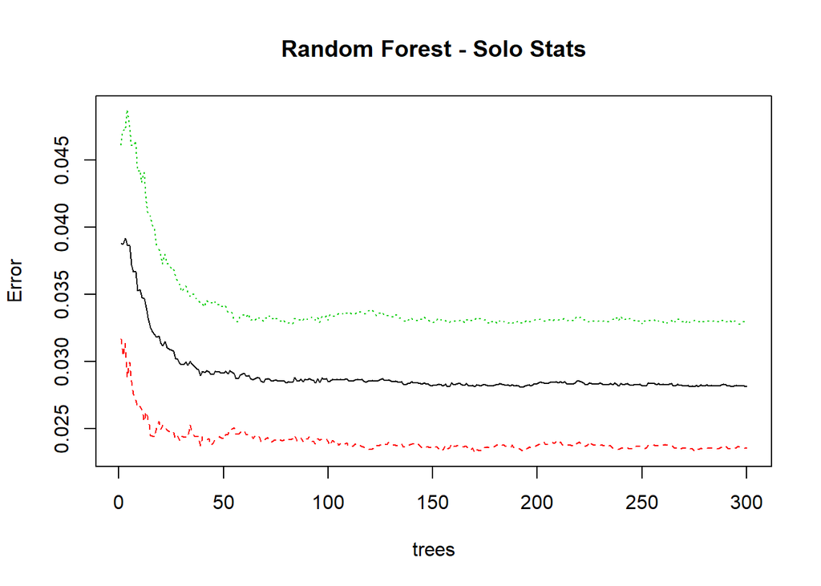

```r
plot(model, main="Random Forest - Solo Stats")
```

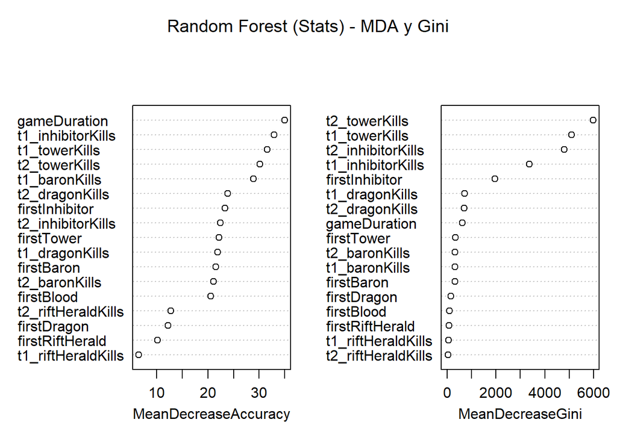

```r
varImpPlot(model, main = "Random Forest (Stats) - MDA y Gini") # Gracias a importance = true
```

Lo exportamos a PDF…

```r
pdf("../imagenes/RandomForest_FT.pdf")
plot(model, main="Random Forest - Solo Stats")
varImpPlot(model, main = "Random Forest (Stats) - MDA y Gini")
dev.off
```

```
## function (which = dev.cur())
## {
##     if (which == 1)
##         stop("cannot shut down device 1 (the null device)")
##     .External(C_devoff, as.integer(which))
##     dev.cur()
## }
## <bytecode: 0x0000000016564710>
## <environment: namespace:grDevices>
```

Vamos a interpretar estos datos del modelo:

- MeanDecreaseAccuracy se refiere al decremento de la exactitud del modelo si se permutan los valores en cada característica. En otras palabras, MDA nos muestra la media de valores que se clasificarían mal si se quitara esa característica de la predicción. Los valores que nos da MDA son la media de las variables que no se clasificarían bien en caso de quitar esas variables del entrenamiento del modelo. En nuestro caso, game duration, los inhibidores y las torres son lo que más información le está aportando al modelo.
- MeanDecreaseGini se refiere a la medida de la ganancia media de pureza mediante la división de cierta variable. Cuanto más importante sea la variable, habrá un mayor descenso en el Gini. La importancia de este está íntimamente relacionada a la función de decisión local, que Random Forest usa para seleccionar cual es la mejor separación. Como vemos, las torres y los inhibidores vuelven a ser cruciales para determinar quién es el ganador de la partida.

```r
result <- rfcv(data.ml.rf, as.factor(data.ml[, 2]), cv.fold=10)
#head(result)
```